# Vylézají z tůní, které vyschly, menší žabky?

Hierarchická data a náhodné efekty — podkladové čtenářské materiály k přednášce

Publikováno

21. října 2026

Upraveno

23. října 2026

Mělké tůně, louže v kolejích a malé mokřady jsou pro obojživelníky nenahraditelné: kladou do nich vajíčka a pulci v nich rostou, dokud se nepromění v malé žabky. Za suchých let ale mnoho takových tůní vyschne a po deštích se znovu naplní. Voda se vrátí, jenže dno, řasy a drobní živočichové, kterými se pulci živí, už nemusejí být stejné jako v tůni, která nikdy nevyschla.

Ekologové proto zkusili v pokusu napodobit tůně, které vyschly a znovu se naplnily, a porovnat je s tůněmi, které nevyschly. Sledovali, jak velké žabky z nich nakonec vylezou. Velikost na konci metamorfózy je u žab důležitá: větší žabky obvykle lépe přežívají první měsíce na souši.

**QuestionHlavní otázka**

Vylézají z tůní, které vyschly a znovu se naplnily, menší žabky? A jak jistě to můžeme z naměřených dat tvrdit?

Na první část otázky odpoví graf a známý lineární model. Druhá část je zrádnější a celá tato lekce se točí kolem ní.

# 1 Co zůstalo otevřené u krabů a u ostrovů?

S podobnou otázkou jsme se už dvakrát setkali, ale pokaždé jsme ji odložili.

Při hledání odpovědi, zda jsou krabi houslisti na severnějších slaniskách větší, jsme nepracovali s jednotlivými kraby. Každý řádek tabulky představoval jedno slanisko a v modelu byly průměrySoučet hodnot vydělený jejich počtem; nejběžnější míra polohy (střední hodnoty). krabů z jednotlivých slanisek. Tehdy jsme si slíbili, že důvod vysvětlíme později, až se budeme zabývat hierarchickými datyData, kde pozorování nejsou zcela nezávislá - jsou seskupena do vyšší úrovně (lokality, bloky, jedinci s opakovanými měřeními)..

V předchozí lekci jsme zase modelovali počty druhů na třiceti ostrovech Galapág. Na konci jsme se ptali, zda je třicet ostrovů jednoho souostroví opravdu třicet nezávislých kousků informace, když si sousední ostrovy vyměňují semena a sdílejí podnebí.

**QuestionZkuste odpovědět dřív, než budete číst dál**

Proč jsme u krabů modelovali průměry slanisek, a ne všechny změřené kraby? Co by se mohlo pokazit, kdybychom každého kraba počítali jako samostatné pozorování?

Odpověď nebudeme hledat u krabů, ale v pokusu s žabkami. Ke krabům se vrátíme, až budeme mít v ruce potřebné nástroje.

# 2 Co se v této lekci naučíte

Po prostudování lekce budete umět:

- pojmenovat hierarchii v datech (opakovaná měření, lokality, bloky) a určit, na které úrovni se mění zkoumaný prediktorProměnná, pomocí níž vysvětlujeme variabilitu odezvy; v notaci y ~ x je prediktor x.;
- určit, které jednotky v datech představují nezávislá opakování, a vysvětlit, jak pseudoreplikaceChyba, kdy závislá pozorování (např. opakovaná měření téže jednotky) analyzujeme, jako by byla nezávislá; nadhodnotí se tím množství informace v datech. zkresluje standardní chybuMíra přesnosti odhadu parametru (průměru, sklonu…); odhaduje z jediného výběru, jak moc by se odhady typicky lišily mezi opakovanými výběry stejné velikosti., intervaly spolehlivostiRozsah hodnot vypočtený z dat postupem, který při opakovaných výběrech pokryje skutečnou hodnotu parametru ve zvoleném podílu případů (typicky 95 %). a p-hodnotyPravděpodobnost, že bychom při platnosti nulové hypotézy pozorovali data alespoň tak extrémní jako naše skutečná data.;
- rozhodnout, zda má být skupinová proměnná pevnýmFaktor v modelu, jehož konkrétní úrovně jsou pro analýzu relevantní a vyčerpávají (nebo reprezentují) všechny zájmové kategorie., nebo náhodným faktoremFaktor ve smíšeném modelu, jehož úrovně považujeme za výběr z většího souboru možných úrovní; zajímá nás rozptyl, který přináší, ne konkrétní úrovně., a zdůvodnit volbu biologickou otázkou;
- odhadnout lineární model s náhodným interceptem, interpretovat jeho výsledek a porovnat variabilitu mezi skupinami a uvnitř skupin;
- popsat, kdy je potřeba model s náhodnými efekty místo jednoduchého `lm()`, a kdy stačí jednodušší řešení.

Kromě toho si postupně navrhnete vlastní terénní studii, ve které se stejné otázky objeví ještě před prvním měřením.

# 3 Žabky z pokusných nádrží

## 3.1 Pokus se 16 nádržemi

Pokus provedli K. J. Ward, S. E. M. Burkhead, E. A. Stybr-Burrus a T. M. Luhring v roce 2021 na terénní stanici Wichita State University v Kansasu (Ward et al. 2023, *Freshwater Biology*). Na louce rozmístili 64 velkých plastových nádrží na vodu pro dobytek, každou o objemu 1 000 litrů, a udělali z nich malé umělé tůně. Polovina nádrží před začátkem pokusu vyschla a byla znovu napuštěna, druhá polovina zůstala celou dobu plná. Do části nádrží potom vysadili po 50 pulcích severoamerického skokana *Lithobates blairi*.

Malé žabky po dokončení metamorfózy vylezly jen z nádrží, ve kterých byli pulci bez dravých ryb. Takových nádrží bylo 16 a s nimi budeme pracovat. Jakmile žabka vylezla z vody, výzkumníci jí změřili délku těla a zvážili ji.

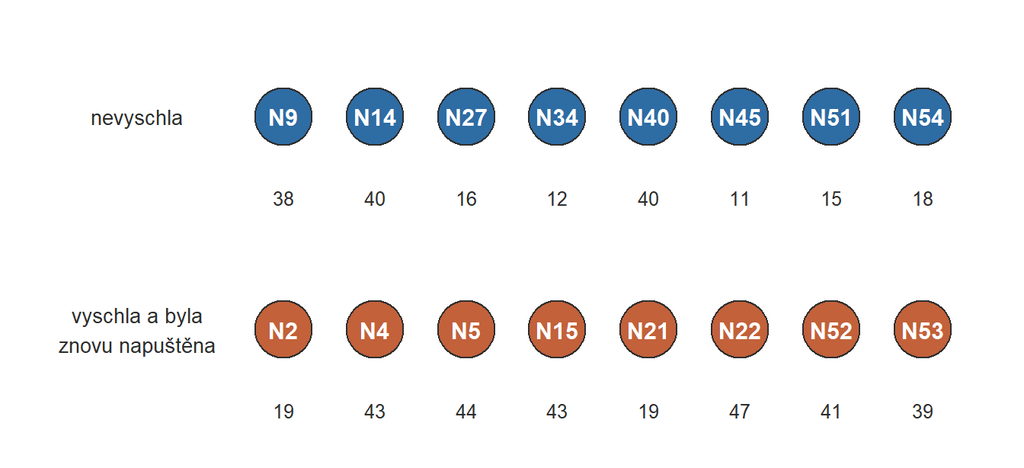

Uspořádání pokusu. Každý kruh je jedna nádrž; popisek uvnitř je označení nádrže (N a číslo nádrže v původním pokusu), číslo pod kruhem počet žabek, které z ní vylezly. O vyschnutí se rozhodovalo vždy pro celou nádrž.

Nejdůležitější vlastnost tohoto pokusu je vidět už na schématu: **vyschnutí se týkalo vždy celé nádrže**, nikoli jednotlivých žabek. Všechny žabky z jedné nádrže vyrůstaly ve stejné vodě, se stejnou potravou a se stejnou historií nádrže.

**TipDoplňující: původ dat a příprava tabulky**

Původní data jsou zveřejněna v repozitáři Dryad ([doi:10.5061/dryad.hx3ffbgkn](https://doi.org/10.5061/dryad.hx3ffbgkn)) pod licencí CC0. Výsledky pokusu popisuje článek Ward et al. (2023), *Freshwater Biology*, [doi:10.1111/fwb.14157](https://doi.org/10.1111/fwb.14157). V tabulce, se kterou pracujeme, jsou jen žabky z 16 nádrží bez ryb. Názvy sloupců jsme přeložili do češtiny, vynechali jsme pomocné hmotnosti vážicích kelímků a suchou hmotnost jsme zaokrouhlili na tisíciny gramu, s jakou přesností se vážilo.

Následující kód stáhne původní soubor ze zrcadla repozitáře Dryad v repozitáři Zenodo, ověří jeho otisk SHA-256 a uloží výukovou tabulku. Potřebuje balíčky `readxl` a `digest`.

```r
# Stáhneme původní soubor z repozitáře Zenodo
cesta_zdroj <-
  tempfile(fileext = ".xlsx")

download.file(
  url = paste0(
    "https://zenodo.org/api/records/8083635/files/",
    "Frog_Metamorph_Data_Dryad.xlsx/content"
  ),
  destfile = cesta_zdroj,
  mode = "wb"
)

# Ověříme, že jsme stáhli přesně očekávaný soubor
stopifnot(
  digest::digest(
    object = cesta_zdroj,
    algo = "sha256",
    file = TRUE
  ) == paste0(
    "cc879383de5a35a7ee57c9e6b446bb9c",
    "364bc9fd7007452e55ba39ea06f2fef4"
  )
)

# Načteme list s údaji o žabkách
data_zdroj <-
  as.data.frame(
    readxl::read_excel(
      path = cesta_zdroj,
      sheet = "Sheet1"
    )
  )

# Sestavíme výukovou tabulku s českými názvy proměnných
data_zabky_priprava <-
  data.frame(
    nadrz = as.integer(data_zdroj$Tank),
    vyschnuti = ifelse(
      test = data_zdroj$Treatment == "A:DR",
      yes = "vyschla",
      no = "nevyschla"
    ),
    poradi_zabky = as.integer(data_zdroj$Indiv),
    datum_metamorfozy = as.Date(data_zdroj$Date),
    den_pokusu = as.integer(data_zdroj$Day),
    delka_tela_mm = data_zdroj$SVL,
    hmotnost_mokra_g = data_zdroj$Wet_Mass,
    hmotnost_sucha_g = round(data_zdroj$Dry_Mass, digits = 3)
  )

# Seřadíme řádky podle nádrže a pořadí žabky
vec_poradi_radku <-
  order(
    data_zabky_priprava$nadrz,
    data_zabky_priprava$poradi_zabky
  )

data_zabky_serazene <-
  data_zabky_priprava[vec_poradi_radku, ]

# Nádrže označíme jako N2, N4, ..., aby se četly jako názvy, ne jako množství
data_zabky_serazene$nadrz <-
  paste0("N", data_zabky_serazene$nadrz)

# Uložíme výukovou tabulku
write.csv(
  x = data_zabky_serazene,
  file = here::here("data", "zabky_nadrze.csv"),
  row.names = FALSE
)
```

Stejný postup obsahuje skript `R/prepare_frog_data.R` v repozitáři lekce.

## 3.2 Jeden řádek tabulky představuje jednu žabku

Každý řádek tabulky popisuje jednu žabku, takže jednotkou pozorováníEntita nebo děj, o kterém jedno pozorování nese informace, například jedinec, plocha, vzorek vody nebo jedna erupce. je žabka. Pro každou žabku známe:

Proměnné ve výukové tabulce žabek z pokusných nádrží.

| Proměnná | Význam | Jednotka |
| --- | --- | --- |
| `nadrz` | označení nádrže, ze které žabka vylezla (N a číslo nádrže v původním pokusu, například `N27`) | — |
| `vyschnuti` | zda nádrž před pokusem vyschla (`vyschla`), nebo ne (`nevyschla`) | — |
| `poradi_zabky` | pořadové číslo žabky v rámci nádrže | — |
| `datum_metamorfozy` | datum, kdy žabka vylezla z vody | datum |
| `den_pokusu` | počet dní od začátku pokusu | den |
| `delka_tela_mm` | délka těla od špičky čenichu ke kloace | mm |
| `hmotnost_mokra_g` | hmotnost živé žabky | g |
| `hmotnost_sucha_g` | hmotnost žabky po vysušení | g |

Hlavní odezvouProměnná, jejíž variabilitu se snažíme vysvětlit nebo předpovědět; v notaci modelu y ~ x je odezva y. bude délka těla. Hlavním prediktoremProměnná, pomocí níž vysvětlujeme variabilitu odezvy; v notaci y ~ x je prediktor x. bude vyschnutí nádrže, tedy kategoriální proměnnáProměnná nabývající hodnot z omezeného počtu kategorií; může být nominální (bez pořadí) nebo ordinální (s pořadím). se dvěma úrovněmi.

Soubor zabky_nadrze.csv je součástí materiálů. Pro následující kód jej uložte do složky `data` ve svém projektu v R. Načteme ho a nastavíme, že referenční skupinouÚroveň kategoriálního prediktoru, vůči které model vyjadřuje rozdíly ostatních skupin; její průměr (při nulových numerických prediktorech) je intercept. budou nádrže, které nevyschly. Označení nádrží převedeme na faktor, aby se nádrže ve výpisech a grafech řadily podle čísla (N2, N4, …, N54), a ne abecedně jako text (N14 před N2):

```r
# Načteme tabulku s jedním řádkem pro každou žabku
data_zabky <-
  read.csv(
    file = here::here("data", "zabky_nadrze.csv")
  )

# Nádrže, které nevyschly, budou referenční skupinou
data_zabky$vyschnuti <-
  factor(
    x = data_zabky$vyschnuti,
    levels = c("nevyschla", "vyschla")
  )

# Nádrže ponecháme v pořadí z tabulky, tedy podle čísla nádrže
data_zabky$nadrz <-
  factor(
    x = data_zabky$nadrz,
    levels = unique(data_zabky$nadrz)
  )
```

Než začneme cokoli modelovat, tabulku prohlédneme: strukturu, chybějící hodnoty a rozsahy hodnot.

```r
# Ověříme datové typy proměnných
str(object = data_zabky)
```

```
'data.frame':   485 obs. of  8 variables:
 $ nadrz            : Factor w/ 16 levels "N2","N4","N5",..: 1 1 1 1 1 1 1 1 1 1 ...
 $ vyschnuti        : Factor w/ 2 levels "nevyschla","vyschla": 2 2 2 2 2 2 2 2 2 2 ...
 $ poradi_zabky     : int  1 2 3 4 5 6 7 8 9 10 ...
 $ datum_metamorfozy: chr  "2021-06-30" "2021-06-30" "2021-06-30" "2021-06-30" ...
 $ den_pokusu       : int  53 53 53 53 56 56 56 56 56 56 ...
 $ delka_tela_mm    : int  25 23 26 24 25 25 25 26 25 26 ...
 $ hmotnost_mokra_g : num  0.9 0.9 1.2 0.9 1.1 0.9 1.3 1.2 1.1 1.2 ...
 $ hmotnost_sucha_g : num  0.137 0.133 0.201 0.131 0.16 0.14 0.217 0.196 0.174 0.198 ...
```

```r
# Minimum, kvartily, průměr a maximum vybraných numerických proměnných
summary(
  object = data_zabky[
    ,
    c("den_pokusu", "delka_tela_mm", "hmotnost_sucha_g")
  ]
)
```

```
   den_pokusu    delka_tela_mm   hmotnost_sucha_g
 Min.   :41.00   Min.   :19.00   Min.   :0.0880
 1st Qu.:49.00   1st Qu.:24.00   1st Qu.:0.1460
 Median :53.00   Median :25.00   Median :0.1780
 Mean   :54.33   Mean   :25.83   Mean   :0.2088
 3rd Qu.:58.00   3rd Qu.:28.00   3rd Qu.:0.2650
 Max.   :82.00   Max.   :35.00   Max.   :0.8510
```

```r
# Spočítáme chybějící hodnoty v každém sloupci
colSums(x = is.na(data_zabky))
```

```
            nadrz         vyschnuti      poradi_zabky datum_metamorfozy
                0                 0                 0                 0
       den_pokusu     delka_tela_mm  hmotnost_mokra_g  hmotnost_sucha_g
                0                 0                 0                 0
```

Tabulka má 485 řádků a žádné chybějící hodnoty. Délka těla se pohybuje od 19 do 35 mm a výzkumníci ji zapisovali na celé milimetry. To odpovídá velikosti žabek krátce po metamorfóze. Suchá hmotnost má mediánHodnota rozdělující seřazená data na dvě stejně početné poloviny; 50% kvantil (prostřední kvartil). 0,178 g, ale největší žabka vážila 0,851 g: rozděleníPopis toho, jaké hodnoty proměnná nabývá a jak často se vyskytují; může jít o pozorované rozdělení dat nebo o teoretické pravděpodobnostní rozdělení. hmotnosti má dlouhý chvost vpravo, podobně jako mnoho velikostí z předchozí lekce.

## 3.3 Kolik žabek vylezlo z které nádrže?

Pro tuto lekci je důležité ještě jedno ověření: kolik řádků patří ke každé nádrži.

```r
# Počet žabek z každé nádrže
table(data_zabky$nadrz)
```

```
 N2  N4  N5  N9 N14 N15 N21 N22 N27 N34 N40 N45 N51 N52 N53 N54
 19  43  44  38  40  43  19  47  16  12  40  11  15  41  39  18
```

```r
# Počet žabek z vyschlých a nevyschlých nádrží
table(data_zabky$vyschnuti)
```

```
nevyschla   vyschla
      190       295
```

Z nádrží vylezlo nestejně mnoho žabek: nejméně 11, nejvíce 47. Z vyschlých nádrží pochází 295 žabek, z nevyschlých jen 190, přestože do každé nádrže bylo na začátku vysazeno stejně pulců.

## 3.4 Jak velké jsou žabky z vyschlých a nevyschlých nádrží?

Začneme houslovým grafem (violin plot)Graf rozdělení numerické proměnné v jedné nebo více skupinách, který zrcadlově kreslí graf hustoty; šířka ‘houslí’ ukazuje, kde jsou hodnoty nahuštěné. délky těla pro obě skupiny nádrží. Šířka „houslí” ukazuje, kolik žabek mělo danou délku; uvnitř je úzký krabicový graf (boxplot)Graf, jehož krabice sahá od Q1 do Q3 a obsahuje medián; vousy vymezují hodnoty podle zvoleného pravidla a body za nimi upozorňují na možná odlehlá pozorování. s mediánem, malé body jsou jednotlivé žabky a velký bod s tmavým okrajem je průměr skupiny.

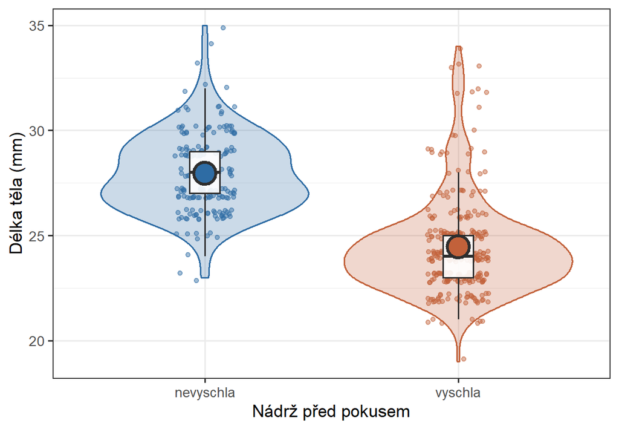

Délka těla žabek z nevyschlých a z vyschlých nádrží. Houslový graf ukazuje rozdělení délek, úzký krabicový graf medián a kvartily, malé body jednotlivé žabky a velký bod s tmavým okrajem průměr skupiny.

**PoznámkaDoplňující: jak nakreslit houslový graf v R**

Základní grafika v R houslový graf nenabízí, a proto použijeme balíček `ggplot2`. Vrstvy se přidávají znaménkem `+`: housle, jednotlivé body a úzký krabicový graf.

```r
# Houslový graf délky těla podle vyschnutí nádrže
ggplot2::ggplot(
  data = data_zabky,
  mapping = ggplot2::aes(
    x = vyschnuti,
    y = delka_tela_mm,
    fill = vyschnuti
  )
) +
  # Housle: rozdělení délek v každé skupině
  ggplot2::geom_violin(alpha = 0.3) +
  # Jednotlivé žabky s malým náhodným posunem do stran
  ggplot2::geom_jitter(
    width = 0.1,
    alpha = 0.4
  ) +
  # Úzký krabicový graf s mediánem a kvartily
  ggplot2::geom_boxplot(
    width = 0.1,
    fill = "white",
    outlier.shape = NA
  ) +
  ggplot2::labs(
    x = "Nádrž před pokusem",
    y = "Délka těla (mm)"
  ) +
  ggplot2::theme_bw(base_size = 14)
```

**QuestionCo vidíte?**

Jak velký je rozdíl mezi žabkami z vyschlých a nevyschlých nádrží? Překrývají se obě skupiny?

Žabky z vyschlých nádrží měřily v průměruSoučet hodnot vydělený jejich počtem; nejběžnější míra polohy (střední hodnoty). 24,5 mm, žabky z nevyschlých 28,0 mm. Rozdíl kolem 3,5 mm je u žabek, které typicky měří 25 mm, velký. Obě skupiny se sice překrývají, ale na první pohled to vypadá jako jasný výsledek.

## 3.5 Stejné žabky rozdělené podle nádrží

Stejná data můžeme rozdělit podle nádrží. Každý sloupec bodů v grafu je jedna nádrž; barva ukazuje, zda nádrž vyschla.

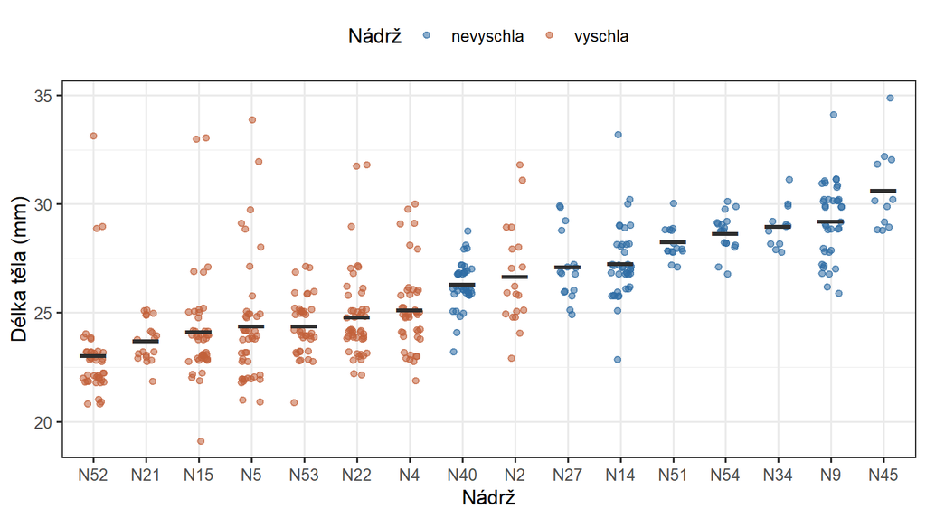

Délka těla žabek v jednotlivých nádržích. Nádrže jsou seřazené podle průměrné délky žabek; černá vodorovná čárka ukazuje průměr nádrže.

**PoznámkaDoplňující: jak si skupiny prohlédnout v R**

U vlastních dat si skupiny prohlédnete jednou funkcí základní grafiky. Funkce `stripchart()` nakreslí jednotlivé hodnoty pro každou nádrž a `method = "jitter"` je mírně rozptýlí do stran, aby se nepřekrývaly. Vodorovné čárky označují průměry nádrží.

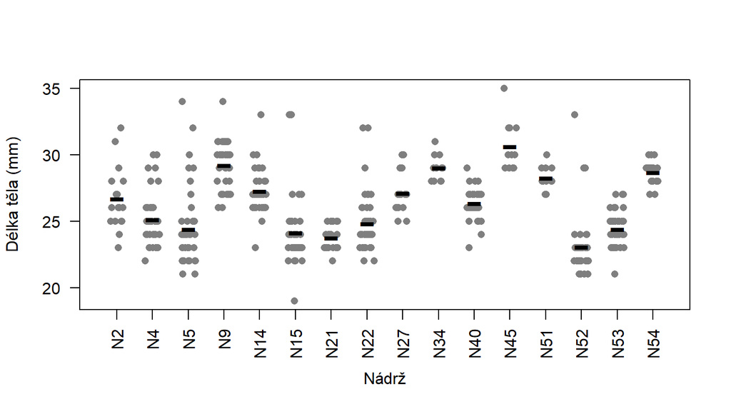

Délka těla žabek v jednotlivých nádržích nakreslená základní grafikou; nádrže jsou v pořadí podle čísla.

```r
set.seed(900723)

# Jednotlivé žabky: jeden sloupec bodů pro každou nádrž
stripchart(
  x = delka_tela_mm ~ nadrz,
  data = data_zabky,
  vertical = TRUE,
  method = "jitter",
  jitter = 0.2,
  pch = 16,
  col = "grey50",
  las = 2,
  xlab = "Nádrž",
  ylab = "Délka těla (mm)"
)

# Průměr každé nádrže jako vodorovná čárka
points(
  x = seq_len(nlevels(data_zabky$nadrz)),
  y = tapply(
    X = data_zabky$delka_tela_mm,
    INDEX = data_zabky$nadrz,
    FUN = mean
  ),
  pch = "-",
  cex = 3
)
```

**QuestionCo mají společného žabky z jedné nádrže?**

Podívejte se na jednu nádrž a porovnejte ji s ostatními. Jsou si žabky z jedné nádrže podobnější než žabky z různých nádrží? Liší se od sebe i nádrže se stejnou úpravou?

Žabky z jedné nádrže mají často podobné délky a nádrže se od sebe liší, i když měly stejnou úpravu. PrůměrySoučet hodnot vydělený jejich počtem; nejběžnější míra polohy (střední hodnoty). nevyschlých nádrží se pohybují od 26,3 do 30,6 mm, průměry vyschlých od 23,0 do 26,7 mm. Každá nádrž měla svou vlastní vodu, své řasy a svou hustotu pulců, a to se na všech jejích žabkách projevilo společně.

**QuestionVaše vlastní studie: otázka a měření**

V této lekci si krok za krokem navrhnete vlastní studii. Vymyslete ekologickou otázku, na kterou byste chtěli odpovědět měřením v terénu. Zapište si:

1. jaký organismus budete měřit a jakou veličinu (s jednotkou);
2. co budete porovnávat (dvě prostředí, gradient, ošetření);
3. kde a jak byste organismy sbírali.

**DůležitéUkázka: larvy vážek v tůních**

1. Larvy vážek; délka těla larvy v mm.
2. Tůně obklopené lesem a tůně mezi poli: mají larvy v lesních tůních jinou velikost?
3. V několika oblastech vybereme lesní a polní tůně a v každé tůni odchytíme síťkou několik larev.

Jde o vymyšlený příklad pro plánování; data k němu nemáme.

# 4 Kolik nezávislých odpovědí máme?

## 4.1 Žabky v nádržích, nádrže v pokusu

Data mají dvě úrovně: žabky jsou seskupené v nádržích a úpravu dostaly celé nádrže, tedy vyschly, nebo nevyschly. Takovým datům říkáme hierarchická dataData, kde pozorování nejsou zcela nezávislá - jsou seskupena do vyšší úrovně (lokality, bloky, jedinci s opakovanými měřeními)..

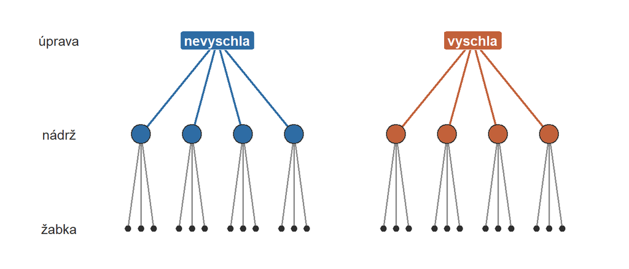

Hierarchie dat v pokusu: úprava (vyschnutí) byla přidělena nádržím, žabky jsou seskupené v nádržích. Schéma ukazuje jen několik nádrží a žabek.

Hierarchie vzniká způsobem sběru dat a v biologii je velmi častá:

- opakovaná měřeníData, kde stejná jednotka (jedinec, lokalita) je měřena opakovaně v čase nebo v různých podmínkách; vytváří korelaci mezi pozorováními.: stejného jedince měříme několikrát, například ve více dnech;
- lokality: na jedné lokalitě změříme mnoho organismů;
- bloky: plochu rozdělíme na části s podobnými podmínkami a v každé části srovnáme několik ošetření.

Ve všech těchto případech jsou si pozorování ze stejné skupiny podobnější než pozorování z různých skupin.

## 4.2 Na které úrovni se rozhodovalo o vyschnutí?

**QuestionKolik nezávislých odpovědí máme?**

Kolik nezávislých odpovědí na otázku „mění vyschnutí tůně velikost žabek?” nám tento pokus dává? Je to 485, nebo jiné číslo?

O vyschnutí se rozhodovalo pro celou nádrž. Pokud by vyschnutí na žabky nemělo žádný vliv, mohlo by se stát, že v nádržích určených k vyschnutí byla shodou okolností horší voda nebo méně potravy. Takovou náhodu může vyrovnat jen víc nádrží, ne víc žabek z téže nádrže.

Proto rozlišujeme dvě různé jednotky:

- **jednotka pozorováníEntita nebo děj, o kterém jedno pozorování nese informace, například jedinec, plocha, vzorek vody nebo jedna erupce.** je to, co popisuje jeden řádek tabulky, tady žabka;
- **jednotka nezávislé replikace** je nejmenší jednotka, které byla úprava přidělena nezávisle na ostatních, tady nádrž.

Na otázku o vyschnutí tedy máme 16 nezávislých odpovědí: 8 vyschlých a 8 nevyschlých nádrží. Díky 485 žabkám přesně víme, jak velké žabky byly v každé nádrži, ale počet nezávislých opakování úpravy se tím nezvyšuje.

Se stejnou situací jsme se už setkali. U krabů houslistů se zeměpisná šířka měnila jen mezi slanisky, u křídlatky se teplota místa původu měnila jen mezi populacemi. V obou případech jsme si poradili tak, že jsme jednotlivé kraby a rostliny zprůměrovali a v modelu měl každý řádek jedno slanisko nebo jednu populaci. Tehdy jsme to udělali bez vysvětlení. Na žabkách ukážeme, proč bylo průměrování správné, co by se stalo bez něj a jaký model umí s takovými daty pracovat jinak: zachová všechna pozorování, a přesto počítá nezávislé skupiny.

## 4.3 Model, který počítá každou žabku zvlášť

Co se stane, když rozdíl mezi žabkami a nádržemi nebudeme brát v úvahu? Odhadneme známý lineární modelStatistický model, v němž je průměrná odezva součtem interceptu a prediktorů násobených koeficienty; lineární je v koeficientech, takže nemusí jít jen o přímku. s kategoriálním prediktoremProměnná, pomocí níž vysvětlujeme variabilitu odezvy; v notaci y ~ x je prediktor x., ve kterém je každá žabka samostatné pozorováníJeden zaznamenaný případ v datech, který obsahuje hodnoty jedné nebo více proměnných..

```r
# Každá žabka je v modelu samostatným pozorováním
mod_vsechny_zabky <-
  lm(
    formula = delka_tela_mm ~ vyschnuti,
    data = data_zabky
  )

# Zobrazíme tabulku koeficientů
summary(object = mod_vsechny_zabky)
```

```
Call:
lm(formula = delka_tela_mm ~ vyschnuti, data = data_zabky)

Residuals:
    Min      1Q  Median      3Q     Max
-5.4576 -1.4576 -0.4576  1.0368  9.5424

Coefficients:
                 Estimate Std. Error t value Pr(>|t|)
(Intercept)       27.9632     0.1551  180.28   <2e-16 ***
vyschnutivyschla  -3.5055     0.1989  -17.63   <2e-16 ***
---
Signif. codes:  0 '***' 0.001 '**' 0.01 '*' 0.05 '.' 0.1 ' ' 1

Residual standard error: 2.138 on 483 degrees of freedom
Multiple R-squared:  0.3914,    Adjusted R-squared:  0.3902
F-statistic: 310.7 on 1 and 483 DF,  p-value: < 2.2e-16
```

```r
# 95% intervaly spolehlivosti koeficientů
confint(object = mod_vsechny_zabky)
```

```
                    2.5 %    97.5 %
(Intercept)      27.65838 28.267936
vyschnutivyschla -3.89632 -3.114741
```

InterceptParametr modelu: odhadnutá hodnota odezvy, když jsou všechny numerické prediktory rovny nule a kategoriální prediktory jsou v referenční skupině; geometricky jde o úsek na ose y. je průměrná délka žabek z nevyschlých nádrží a koeficient `vyschnutivyschla` rozdíl vyschlých nádrží oproti referenční skupiněÚroveň kategoriálního prediktoru, vůči které model vyjadřuje rozdíly ostatních skupin; její průměr (při nulových numerických prediktorech) je intercept.. Podle modelu jsou žabky z vyschlých nádrží v průměru o 3,51 mm menší, se standardní chybouMíra přesnosti odhadu parametru (průměru, sklonu…); odhaduje z jediného výběru, jak moc by se odhady typicky lišily mezi opakovanými výběry stejné velikosti. 0,199 mm. 95% interval spolehlivostiRozsah hodnot vypočtený z dat postupem, který při opakovaných výběrech pokryje skutečnou hodnotu parametru ve zvoleném podílu případů (typicky 95 %). sahá od -3,90 do -3,11 mm. Model má 483 residuálních stupňů volnostiPočet nezávislých informací dostupných pro odhad parametru; počet pozorování minus počet odhadovaných parametrů. a p-hodnotaPravděpodobnost, že bychom při platnosti nulové hypotézy pozorovali data alespoň tak extrémní jako naše skutečná data. je mnohem menší než 0,001. Výsledek vypadá velmi jistě. Koeficient determinace R²Podíl variability odezvy zachycený modelem: R² = 1 − RSS / celkový součet čtverců (0 = model nezachytí nic navíc oproti průměru, 1 = zachytí vše). je 0,39: vyschnutí zachycuje asi 39 % variability v délce žabek.

Jako u každého lineárního modelu zkontrolujeme residuaRozdíl mezi pozorovanou hodnotou odezvy a hodnotou odhadnutou modelem: eᵢ = yᵢ − ŷᵢ.: jejich histogram a graf residuíDiagnostický bodový graf residuí proti odhadnutým hodnotám (nebo prediktoru); vzor v něm ukazuje na nelinearitu nebo nekonstantní rozptyl. proti odhadnutým hodnotám.

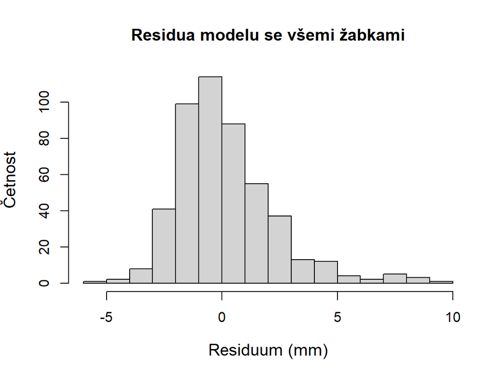

```r
# Residua modelu, který počítá každou žabku zvlášť
vec_residua_vsechny <-
  residuals(object = mod_vsechny_zabky)

# Histogram residuí
hist(
  x = vec_residua_vsechny,
  breaks = 20,
  main = "Residua modelu se všemi žabkami",
  xlab = "Residuum (mm)",
  ylab = "Četnost",
  cex.lab = 1.2
)
```

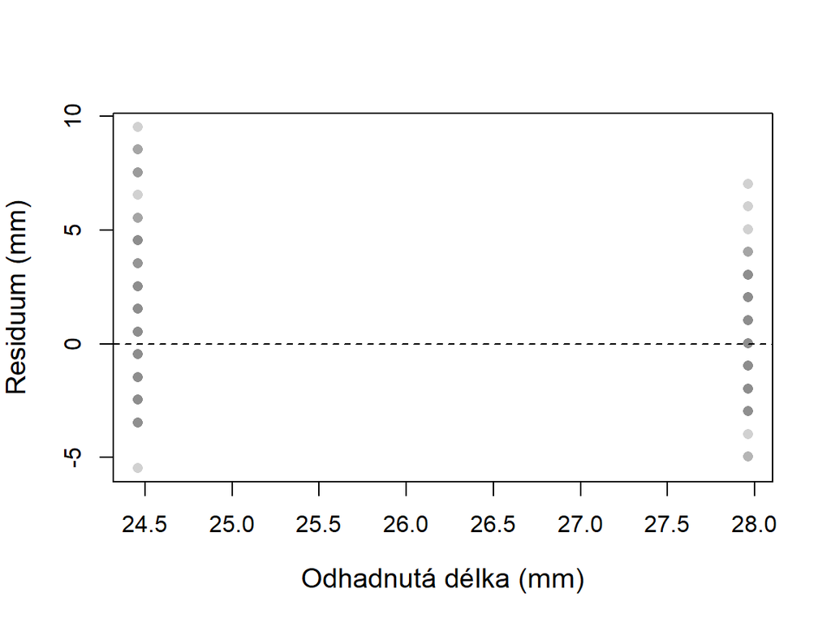

```r
# Residua proti odhadnutým hodnotám
plot(
  x = fitted(object = mod_vsechny_zabky),
  y = vec_residua_vsechny,
  xlab = "Odhadnutá délka (mm)",
  ylab = "Residuum (mm)",
  pch = 16,
  col = "#8C8C8C66",
  cex.lab = 1.2
)

abline(
  h = 0,
  lty = 2
)
```

Histogram je pravostranně šikmý a residua mají v obou skupinách podobné rozptýlení. Protože prediktor má jen dvě hodnoty, tvoří body v grafu residuí dva svislé sloupce. Tvar residuí posoudíme pořádně u správného modelu; z těchto grafů se zatím nezdá, že by s modelem bylo něco zásadně v nepořádku. Jak jsme ale viděli u přímky pro kosatce, graf residuí sám nepozná, že několik měření pochází ze stejné skupiny. Musíme residua seřadit podle nádrží:

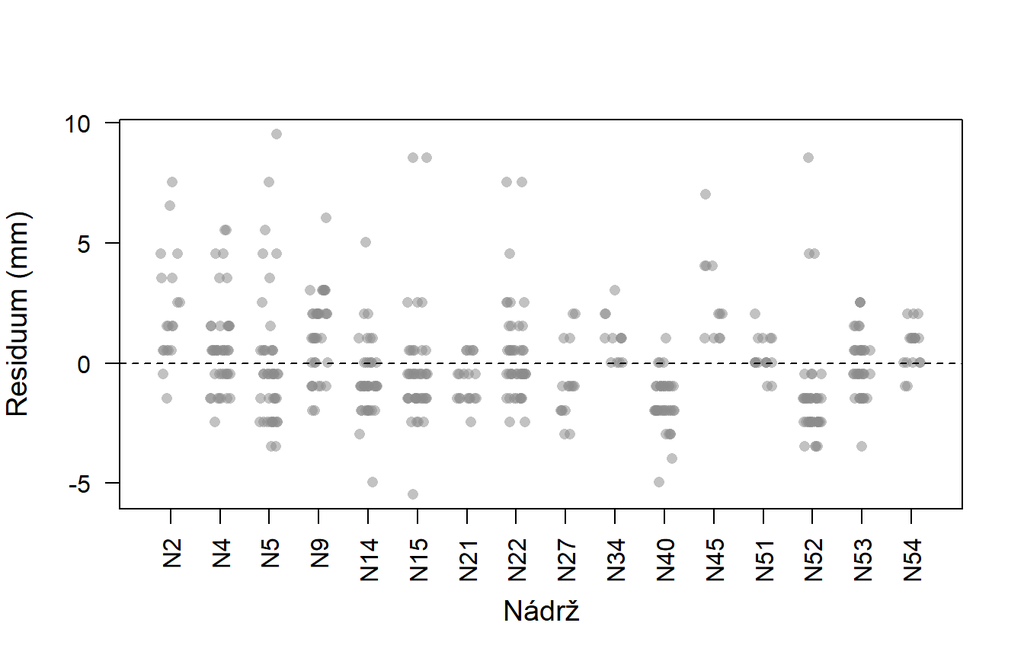

```r
# Residua rozdělená podle nádrží
stripchart(
  x = vec_residua_vsechny ~ data_zabky$nadrz,
  vertical = TRUE,
  method = "jitter",
  jitter = 0.2,
  pch = 16,
  col = "#8C8C8C88",
  xlab = "Nádrž",
  ylab = "Residuum (mm)",
  cex.lab = 1.2,
  # Svislé popisky osy, aby se vešla označení všech nádrží
  las = 2
)

abline(
  h = 0,
  lty = 2
)
```

Residua žabek z jedné nádrže leží často společně nad nulou, nebo společně pod nulou. U 6 z 16 nádrží se průměrné residuum liší od nuly o více než 1 mm. Model tedy u celých nádrží systematicky přeceňuje nebo podceňuje délku žabek. **Residua nejsou nezávislá**: žabky z jedné nádrže se od modelu odchylují podobně.

**UpozorněníLineární model potřebuje nezávislá pozorování**

U přímky pro kosatce jsme sledovali čtyři věci, které musí být rozumné, aby lineární model odpovídal na otázku: tvar vztahu, rozptýlení kolem přímky, tvar residuí a nezávislost pozorování. Tvar residuí, tedy zda se blíží normálnímu rozděleníSouměrné zvonovité pravděpodobnostní rozdělení určené průměrem a směrodatnou odchylkou; lineární model předpokládá přibližně normální rozdělení residuí., jsme podrobně posuzovali v předchozí lekci. U žabek selhává čtvrtá podmínka: žabky z jedné nádrže nejsou nezávislá pozorování. R model spočítá i tak a na nic neupozorní. Jeho standardní chyba, interval spolehlivosti i p-hodnota ale počítají s tím, že každá žabka přináší novou nezávislou informaci. **Pro otázku o vyschnutí proto tento model není správný**, i když jeho tabulka koeficientů vypadá stejně jako u kteréhokoli jiného modelu.

## 4.4 Model, který počítá každou nádrž jednou

Druhá možnost je postup, který jsme použili u krabů: spočítáme průměrSoučet hodnot vydělený jejich počtem; nejběžnější míra polohy (střední hodnoty). každé nádrže a model odhadneme z průměrů. Každá nádrž tak bude v modelu jen jednou.

```r
# Průměrná délka žabek v každé nádrži
data_nadrze <-
  aggregate(
    x = delka_tela_mm ~ nadrz + vyschnuti,
    data = data_zabky,
    FUN = mean
  )

# Tabulka má jeden řádek pro každou nádrž
nrow(x = data_nadrze)
```

```
[1] 16
```

```r
# Každá nádrž je v modelu jedním pozorováním
mod_prumery_nadrzi <-
  lm(
    formula = delka_tela_mm ~ vyschnuti,
    data = data_nadrze
  )

# Zobrazíme tabulku koeficientů a intervaly spolehlivosti
summary(object = mod_prumery_nadrzi)
```

```
Call:
lm(formula = delka_tela_mm ~ vyschnuti, data = data_nadrze)

Residuals:
     Min       1Q   Median       3Q      Max
-1.98815 -0.86922 -0.09299  0.61405  2.32321

Coefficients:
                 Estimate Std. Error t value Pr(>|t|)
(Intercept)       28.3132     0.4366  64.853  < 2e-16 ***
vyschnutivyschla  -3.7634     0.6174  -6.095 2.76e-05 ***
---
Signif. codes:  0 '***' 0.001 '**' 0.01 '*' 0.05 '.' 0.1 ' ' 1

Residual standard error: 1.235 on 14 degrees of freedom
Multiple R-squared:  0.7263,    Adjusted R-squared:  0.7068
F-statistic: 37.15 on 1 and 14 DF,  p-value: 2.764e-05
```

```r
confint(object = mod_prumery_nadrzi)
```

```
                     2.5 %    97.5 %
(Intercept)      27.376788 29.249517
vyschnutivyschla -5.087618 -2.439179
```

V modelu z průměrů nádrží je rozdíl vyschlých nádrží -3,76 mm se standardní chybouMíra přesnosti odhadu parametru (průměru, sklonu…); odhaduje z jediného výběru, jak moc by se odhady typicky lišily mezi opakovanými výběry stejné velikosti. 0,617 mm a modelu zbývá jen 14 stupňů volnostiPočet nezávislých informací dostupných pro odhad parametru; počet pozorování minus počet odhadovaných parametrů.. Koeficient determinace je 0,73. S hodnotou 0,39 z modelu se všemi žabkami ho ale porovnat nemůžeme: podobně jako u porovnávání modelů pomocí AIC platí, že R² lze srovnávat jen mezi modely se stejnou odezvou a stejnými pozorováními. Tady model popisuje průměry nádrží, a ty kolísají méně než jednotlivé žabky.

Residua tohoto modelu jsou odchylky průměrů nádrží od průměru jejich skupiny. Je jich jen 16, proto stačí jeden graf:

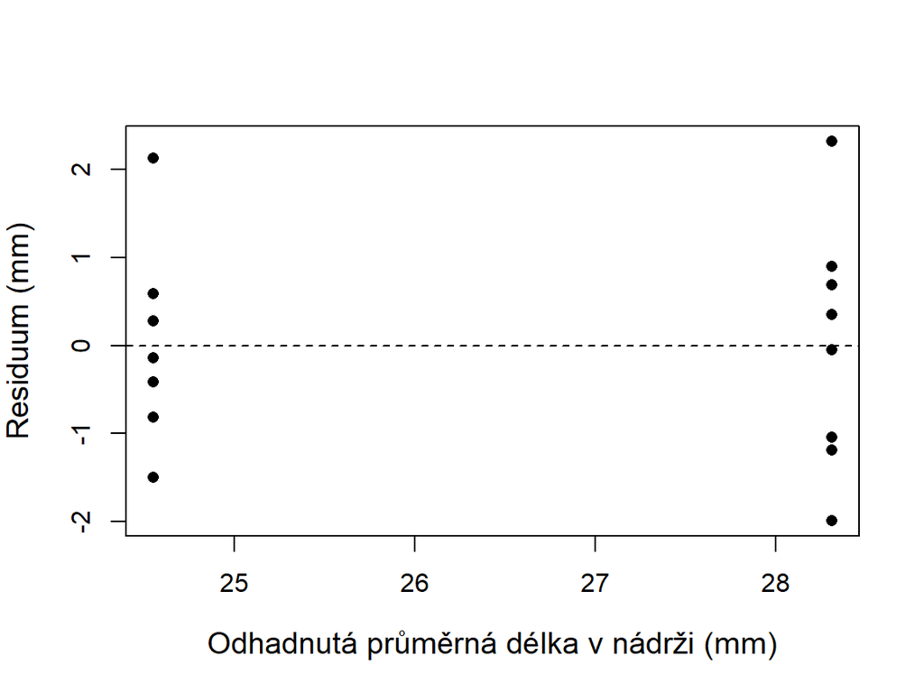

```r
# Residua proti odhadnutým hodnotám pro model z průměrů nádrží
plot(
  x = fitted(object = mod_prumery_nadrzi),
  y = residuals(object = mod_prumery_nadrzi),
  xlab = "Odhadnutá průměrná délka v nádrži (mm)",
  ylab = "Residuum (mm)",
  pch = 16,
  cex.lab = 1.2
)

abline(
  h = 0,
  lty = 2
)
```

Obě skupiny nádrží mají podobné rozptýlení residuí a žádná nádrž nevybočuje. Každý bod je v tomto modelu jedna nezávislá nádrž, takže problém s podobností žabek z jedné nádrže tento model nemá.

## 4.5 Který model je přesnější: všechny žabky, nebo průměry nádrží?

**QuestionNež se podíváte na srovnání**

Který z obou modelů dá podle vás širší interval spolehlivostiRozsah hodnot vypočtený z dat postupem, který při opakovaných výběrech pokryje skutečnou hodnotu parametru ve zvoleném podílu případů (typicky 95 %). pro rozdíl mezi vyschlými a nevyschlými nádržemi? Proč?

Stejná otázka, dva modely: rozdíl délky žabek z vyschlých nádrží oproti nevyschlým.

| Model | Počet pozorování | Rozdíl (mm) | SE (mm) | 95% CI (mm) | df |
| --- | --- | --- | --- | --- | --- |
| Každá žabka zvlášť | 485 | -3,51 | 0,199 | [-3,90; -3,11] | 483 |
| Každá nádrž jednou | 16 | -3,76 | 0,617 | [-5,09; -2,44] | 14 |

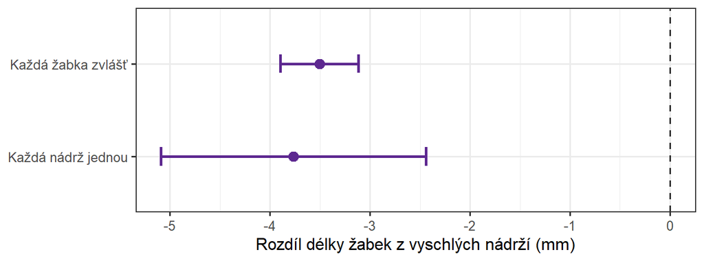

Odhad rozdílu délky žabek z vyschlých nádrží a jeho 95% interval spolehlivosti podle dvou modelů.

Odhad rozdílu se mezi oběma modely téměř nezměnil. **Standardní chybaMíra přesnosti odhadu parametru (průměru, sklonu…); odhaduje z jediného výběru, jak moc by se odhady typicky lišily mezi opakovanými výběry stejné velikosti. je ale v modelu průměrů nádrží 3,1krát větší a interval spolehlivosti je odpovídajícím způsobem širší.** Stupně volnostiPočet nezávislých informací dostupných pro odhad parametru; počet pozorování minus počet odhadovaných parametrů. klesly z 483 na 14. Rozdíl mezi vyschlými a nevyschlými nádržemi zůstal jasný i v poctivém modelu, jen víme méně přesně, jak je velký.

## 4.6 Proč 16 nádrží nevydá za 485 žabek

Při práci s nejistotou odhadu jsme viděli, že standardní chybaMíra přesnosti odhadu parametru (průměru, sklonu…); odhaduje z jediného výběru, jak moc by se odhady typicky lišily mezi opakovanými výběry stejné velikosti. se zmenšuje s počtem nezávislých pozorování. Model, který počítá každou žabku zvlášť, předpokládá, že každá z 485 žabek přináší novou, nezávislou informaci o vlivu vyschnutí. Žabky z jedné nádrže si ale jsou podobné: sdílejí vodu, potravu i hustotu pulců. Druhá žabka ze stejné nádrže proto o vyschnutí neřekne skoro nic nového, co by už neřekla první.

Model se všemi žabkami tak „vidí” mnohem víc nezávislé informace, než ve skutečnosti máme. Důsledkem je **příliš malá standardní chyba, příliš úzký interval spolehlivostiRozsah hodnot vypočtený z dat postupem, který při opakovaných výběrech pokryje skutečnou hodnotu parametru ve zvoleném podílu případů (typicky 95 %)., příliš mnoho stupňů volnostiPočet nezávislých informací dostupných pro odhad parametru; počet pozorování minus počet odhadovaných parametrů. a příliš malá p-hodnotaPravděpodobnost, že bychom při platnosti nulové hypotézy pozorovali data alespoň tak extrémní jako naše skutečná data..** Tuto chybu nazýváme pseudoreplikaceChyba, kdy závislá pozorování (např. opakovaná měření téže jednotky) analyzujeme, jako by byla nezávislá; nadhodnotí se tím množství informace v datech.: závislá pozorování analyzujeme, jako by byla nezávislá opakování.

Pseudoreplikace má praktický důsledek, který známe z testování hypotéz. Když je standardní chyba příliš malá, testová statistikaČíslo vypočtené z dat, které porovnáváme s referenčním rozdělením platným při nulové hypotéze; z tohoto porovnání získáme p-hodnotu. vychází příliš velká a model častěji ohlásí efekt i tam, kde žádný není. Chyba I. typuZamítnutí nulové hypotézy, která ve skutečnosti platí; její pravděpodobnost je rovna zvolené hladině významnosti α. (falešný poplach) je pak mnohem pravděpodobnější, než udává zvolená hladina významnostiPředem zvolená hranice pro p-hodnotu (typicky α = 0,05); je to zároveň přijatelná pravděpodobnost chyby I. typu, tedy zamítnutí platné nulové hypotézy..

**PoznámkaPravidlo pro analýzu**

Počet nezávislých odpovědí na otázku určuje úroveň, na které se mění zkoumaný prediktor. Když se prediktor mění jen mezi skupinami, rozhoduje počet skupin, ne počet řádků.

## 4.7 Pomůže změřit víc žabek z každé nádrže?

**QuestionCo by pomohlo víc?**

Představte si, že pokus opakujete a chcete rozdíl mezi vyschlými a nevyschlými nádržemi odhadnout přesněji. Co pomůže nejvíc?

1. Změřit v každé z 16 nádrží dvakrát víc žabek.
2. Použít dvakrát víc nádrží a v každé změřit stejný počet žabek jako dosud.
3. Měřit žabky přesněji, na desetiny milimetru.
4. Obě možnosti a) a b) pomohou stejně.

**DůležitéŘešení**

**Správně je b).**

- 1. Víc žabek z jedné nádrže zpřesní odhad průměruSoučet hodnot vydělený jejich počtem; nejběžnější míra polohy (střední hodnoty). této nádrže. Nádrže se ale od sebe liší i bez ohledu na vyschnutí a tuto variabilituObecný termín pro rozsah, v němž se hodnoty proměnné liší od sebe navzájem; kvantifikuje se pomocí rozptylu, SD, IQR nebo rozsahu. víc žabek z téže nádrže nezmenší. Od určitého počtu žabek už přesnost téměř neroste.
- 2. Každá nová nádrž je nová nezávislá odpověď na otázku o vyschnutí. Právě jejich počet rozhoduje o přesnosti odhadu.
- 3. Přesnější měření zmenší jen malou část variability mezi žabkami; rozdíly mezi nádržemi zůstanou.
- 4. Obě možnosti nepomohou stejně, viz a) a b).

**UpozorněníČastá chyba: víc řádků znamená víc informace**

Velký počet řádků v tabulce neznamená velký počet nezávislých opakování. Rozhoduje, kolik jednotek dostalo zkoumanou úpravu nebo se liší zkoumaným prediktorem nezávisle na ostatních.

## 4.8 Proč jsme u krabů a křídlatky pracovali s průměry

Stejná úvaha odpovídá na otázku, kterou jsme si položili u krabů. Zeměpisná šířka se mění jen mezi slanisky: všichni krabi z jednoho slaniska mají stejnou zeměpisnou šířku. Na otázku, zda jsou krabi na severu větší, tedy máme 13 nezávislých odpovědí, ne 392. Kdybychom do modelu dali všechny kraby, standardní chybaMíra přesnosti odhadu parametru (průměru, sklonu…); odhaduje z jediného výběru, jak moc by se odhady typicky lišily mezi opakovanými výběry stejné velikosti. sklonuParametr lineárního modelu udávající, o kolik se v průměru liší odezva dvou pozorování, jejichž prediktor se liší o jednu jednotku (při stejných hodnotách ostatních prediktorů). by vyšla 0,034 mm na stupeň. Z průměrůSoučet hodnot vydělený jejich počtem; nejběžnější míra polohy (střední hodnoty). slanisek vychází 0,079 mm na stupeň, tedy zhruba 2,4krát víc. Průměry slanisek byly poctivé řešení.

Stejně jsme postupovali u křídlatky: tloušťku listů jednotlivých rostlin jsme zprůměrovali za každou populaci, protože teplota místa původu se mění jen mezi populacemi.

## 4.9 Co průměry nádrží zahodí

Model z průměrůSoučet hodnot vydělený jejich počtem; nejběžnější míra polohy (střední hodnoty). je poctivý, ale má svou cenu:

- nádrž s 11 žabkami a nádrž se 47 žabkami se v něm počítají stejně, ačkoli průměr větší nádrže je mnohem přesnější;
- ztratíme informaci o rozdílech mezi žabkami uvnitř nádrže;
- nemůžeme použít prediktoryProměnná, pomocí níž vysvětlujeme variabilitu odezvy; v notaci y ~ x je prediktor x., které se mění u jednotlivých žabek, například den, kdy žabka vylezla z vody.

Zůstává tedy otázka: dá se sestavit model, který zachová každou žabku, a přesto bude počítat nezávislé nádrže, a ne nezávislé žabky?

**QuestionVaše vlastní studie: kolik nezávislých odpovědí?**

Vraťte se ke své studii. Na které úrovni se mění prediktor, který vás zajímá? Co je ve vaší studii jednotkou nezávislé replikace? Kolik takových jednotek byste reálně zvládli prozkoumat a kolik měření byste udělali v každé z nich?

**DůležitéUkázka: larvy vážek v tůních**

Okolí tůně (les nebo pole) se mění mezi tůněmi, ne mezi larvami. Jednotkou nezávislé replikace je proto tůň. Raději prozkoumáme víc tůní s menším počtem larev, například 24 tůní po 10 larvách, než 4 tůně po 60 larvách.

# 5 Nádrž jako další prediktor?

## 5.1 Co se stane, když přidáme nádrž do modelu?

Z předchozích lekcí víme, že do modelu můžeme přidat další prediktorProměnná, pomocí níž vysvětlujeme variabilitu odezvy; v notaci y ~ x je prediktor x.. Nabízí se tedy přidat nádrž jako kategoriální prediktor, aby model věděl, která žabka je z které nádrže.

**QuestionPředpovězte výsledek**

Co podle vás model vypíše pro rozdíl mezi vyschlými a nevyschlými nádržemi, když do něj přidáme nádrž jako kategoriální prediktor?

```r
# Nádrž přidáme jako kategoriální prediktor před vyschnutí
mod_nadrz_pevne <-
  lm(
    formula = delka_tela_mm ~ nadrz + vyschnuti,
    data = data_zabky
  )

# Zobrazíme celý souhrn modelu
summary(object = mod_nadrz_pevne)
```

```
Call:
lm(formula = delka_tela_mm ~ nadrz + vyschnuti, data = data_zabky)

Residuals:
    Min      1Q  Median      3Q     Max
-5.1395 -1.1395 -0.2667  0.7250  9.9512

Coefficients: (1 not defined because of singularities)
                 Estimate Std. Error t value Pr(>|t|)
(Intercept)       26.6842     0.4359  61.219  < 2e-16 ***
nadrzN4           -1.5447     0.5234  -2.951 0.003323 **
nadrzN5           -2.2751     0.5216  -4.362 1.59e-05 ***
nadrzN9            2.5263     0.5338   4.732 2.94e-06 ***
nadrzN14           0.5908     0.5294   1.116 0.264989
nadrzN15          -2.5447     0.5234  -4.862 1.59e-06 ***
nadrzN21          -2.9474     0.6164  -4.781 2.33e-06 ***
nadrzN22          -1.8544     0.5165  -3.590 0.000365 ***
nadrzN27           0.4408     0.6447   0.684 0.494479
nadrzN34           2.3158     0.7006   3.306 0.001021 **
nadrzN40          -0.3592     0.5294  -0.679 0.497755
nadrzN45           3.9522     0.7198   5.490 6.58e-08 ***
nadrzN51           1.5825     0.6562   2.411 0.016275 *
nadrzN52          -3.6354     0.5273  -6.895 1.75e-11 ***
nadrzN53          -2.2740     0.5316  -4.278 2.29e-05 ***
nadrzN54           1.9825     0.6249   3.172 0.001612 **
vyschnutivyschla       NA         NA      NA       NA
---
Signif. codes:  0 '***' 0.001 '**' 0.01 '*' 0.05 '.' 0.1 ' ' 1

Residual standard error: 1.9 on 469 degrees of freedom
Multiple R-squared:  0.5334,    Adjusted R-squared:  0.5184
F-statistic: 35.74 on 15 and 469 DF,  p-value: < 2.2e-16
```

Tabulka koeficientů má pro každou nádrž kromě referenční vlastní řádek: rozdíl průměru této nádrže oproti nádrži N2. V posledním řádku, u vyschnutí, ale místo čísel stojí `NA` a nad tabulkou R upozorňuje `(1 not defined because of singularities)`: jeden koeficient nešel odhadnout. Rozdíl mezi vyschlými a nevyschlými nádržemi model neodhadl.

**TipDoplňující: co se stane s opačným pořadím prediktorů**

Když v zápisu modelu uvedeme vyschnutí před nádrží (`delka_tela_mm ~ vyschnuti + nadrz`), R vypíše pro vyschnutí číslo -1,98 mm a místo toho vynechá nádrž N54. Toto číslo ale není vliv vyschnutí. Je to jen rozdíl mezi průměrem nádrže N2 (26,68 mm) a nádrže N54 (28,67 mm). Podle toho, kterou nádrž R vynechá, by vyšlo pokaždé jiné číslo.

## 5.2 Vyschnutí a nádrž nesou stejnou informaci

Proč model selhal? Každá nádrž buď vyschla, nebo nevyschla. Jakmile má každá nádrž v modelu vlastní koeficient, je v nich zahrnuto i vyschnutí: průměrSoučet hodnot vydělený jejich počtem; nejběžnější míra polohy (střední hodnoty). vyschlých nádrží je jen průměr několika nádrží. Pro samostatný koeficient vyschnutí už v datech nezbývá žádná informace.

Dobře to ukáže mřížka modelu. Každý řádek zastupuje všechny žabky jedné nádrže (nádrže jsou seřazené jako ve schématu pokusu), každý sloupec jeden koeficient modelu s nádrží jako kategoriálním prediktorem a poslední sloupec koeficient vyschnutí. Jednička znamená, že sloupec patří k řádku. Mřížka pro přehlednost ukazuje všechny nádrže; v R se jedna nádrž stává referenční a její úroveň je součástí interceptu, takže pro ni tabulka koeficientů nemá vlastní řádek.

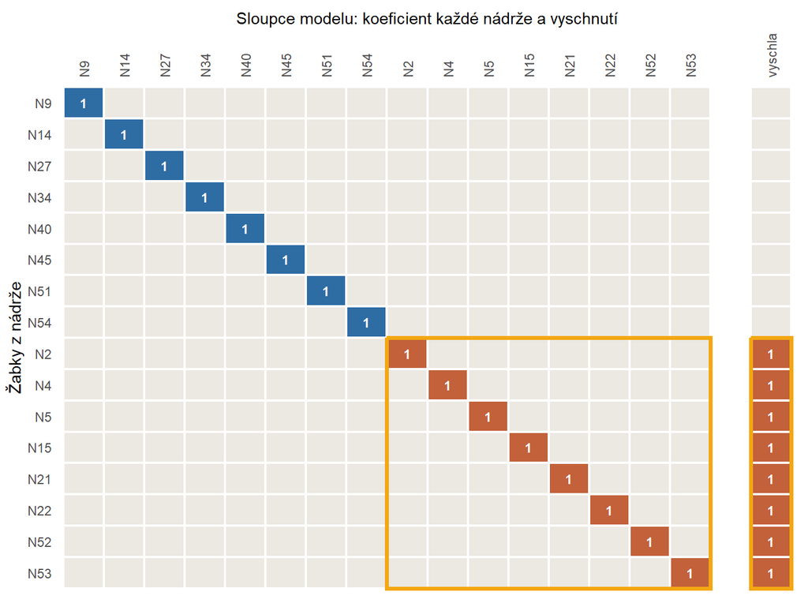

Mřížka modelu s nádrží jako kategoriálním prediktorem. Řádky jsou nádrže, sloupce koeficienty jednotlivých nádrží a oddělený sloupec vyschla. Oranžové rámečky ukazují, že sloupec vyschla je součtem sloupců vyschlých nádrží.

Sloupec `vyschla` má jedničky přesně v řádcích vyschlých nádrží, tedy tam, kde je mají sloupce vyschlých nádrží: je to jejich **součet** (oranžové rámečky). Tuto mřížku vidí R, když vypíše `NA` a hlášku `not defined because of singularities`: sloupec, který se dá poskládat z jiných sloupců, nenese žádnou novou informaci, a jeho koeficient proto nejde odhadnout.

Nádrž jsme tu použili jako pevný faktorFaktor v modelu, jehož konkrétní úrovně jsou pro analýzu relevantní a vyčerpávají (nebo reprezentují) všechny zájmové kategorie.: kategoriální prediktor, jehož každá úroveň má v modelu vlastní koeficient a jehož konkrétní úrovně nás zajímají. Z toho plyne obecné pravidlo:

**PoznámkaPravidlo pro analýzu**

Prediktor, který se mění jen mezi skupinami, nemůže být v modelu zároveň se skupinou jako pevným faktorem. Skupina by „spotřebovala” všechnu informaci, ze které by se jeho vliv dal odhadnout.

Pravidlo se týká prediktoru, který se mění jen mezi nádržemi. Vymyšlený pokus, ve kterém by se úprava měnila uvnitř nádrží, vypadá jinak: každá ze čtyř nádrží je přepážkou rozdělená na polovinu, kde pulce přikrmujeme, a polovinu bez krmení. Data k němu nemáme, slouží jen k porovnání mřížek.

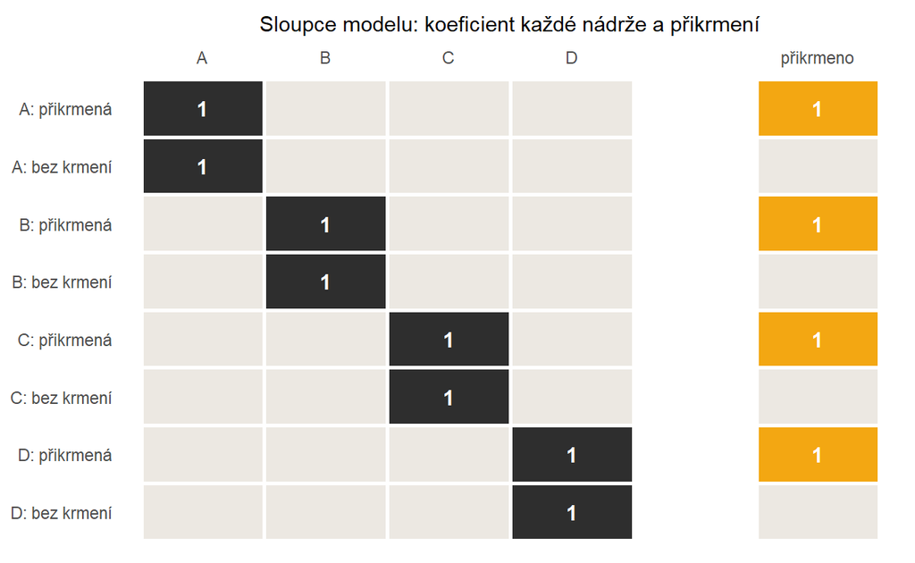

Mřížka modelu pro vymyšlený pokus se čtyřmi nádržemi A až D, každou rozdělenou na přikrmenou polovinu a polovinu bez krmení. Řádky jsou poloviny nádrží, sloupce koeficienty nádrží a oddělený sloupec přikrmeno.

Sloupec `přikrmeno` tu není součtem sloupců nádrží, protože jedničku má v každé nádrži jen u jedné poloviny. Když se úprava mění **uvnitř** nádrží, model ji proto může odhadnout vedle nádrže jako pevného faktoru: porovná poloviny uvnitř každé nádrže a rozdíly mezi nádržemi z porovnání odstraní. Takovou proměnnou v datech žabek máme: den metamorfózy, který se mění uvnitř každé nádrže, jak ukazuje následující část.

## 5.3 Souvisí den metamorfózy s délkou žabky?

Nádrž jako pevný faktorFaktor v modelu, jehož konkrétní úrovně jsou pro analýzu relevantní a vyčerpávají (nebo reprezentují) všechny zájmové kategorie. ale v jiné situaci velmi pomůže. Žabky z jedné nádrže nevylezly z vody najednou: první vylezly po 41 dnech od začátku pokusu, poslední po 82 dnech. Den metamorfózy se tedy mění **uvnitř** nádrží, u jednotlivých žabek. Jsou žabky, které vylezly později, větší, nebo menší?

**QuestionPředpovězte směr vztahu**

Pulec, který zůstane ve vodě déle, má víc času růst. Čekali byste, že žabky, které vylezly později, budou větší? Co asi ukáže model, který nádrže nebere v úvahu?

```r
# Vztah délky ke dni metamorfózy bez ohledu na nádrže
mod_den <-
  lm(
    formula = delka_tela_mm ~ den_pokusu,
    data = data_zabky
  )

# Stejný vztah uvnitř nádrží: nádrž jako kategoriální prediktor
mod_den_nadrz <-
  lm(
    formula = delka_tela_mm ~ den_pokusu + nadrz,
    data = data_zabky
  )

# Porovnáme odhad sklonu dne v obou modelech (zaokrouhleno)
round(
  x = coef(summary(mod_den))["den_pokusu", ],
  digits = 3
)
```

```
  Estimate Std. Error    t value   Pr(>|t|)
    -0.007      0.018     -0.399      0.690
```

```r
round(
  x = coef(summary(mod_den_nadrz))["den_pokusu", ],
  digits = 3
)
```

```
  Estimate Std. Error    t value   Pr(>|t|)
     0.233      0.012     19.437      0.000
```

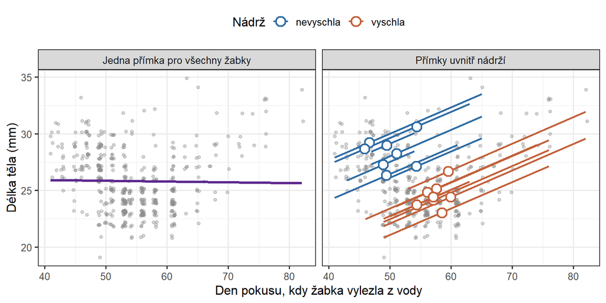

Délka žabky podle dne, kdy vylezla z vody. Vlevo jedna přímka pro všechny žabky, vpravo stejná data s přímkami uvnitř jednotlivých nádrží z modelu s nádrží jako kategoriálním prediktorem. Velké prázdné kruhy ukazují pro každou nádrž průměrný den a průměrnou délku jejích žabek.

Bez ohledu na nádrže vychází sklonParametr lineárního modelu udávající, o kolik se v průměru liší odezva dvou pozorování, jejichž prediktor se liší o jednu jednotku (při stejných hodnotách ostatních prediktorů). -0,007 mm za den s p-hodnotouPravděpodobnost, že bychom při platnosti nulové hypotézy pozorovali data alespoň tak extrémní jako naše skutečná data. 0,69: žádný zřetelný vztah. Když ale do modelu přidáme nádrž, sklon vyjde 0,23 mm za den se standardní chybouMíra přesnosti odhadu parametru (průměru, sklonu…); odhaduje z jediného výběru, jak moc by se odhady typicky lišily mezi opakovanými výběry stejné velikosti. 0,012 mm. **Uvnitř každé nádrže jsou žabky, které vylezly později, zřetelně větší**, za deset dní navíc v průměruSoučet hodnot vydělený jejich počtem; nejběžnější míra polohy (střední hodnoty). asi o 2,3 mm.

## 5.4 Proč se vztah ukázal až uvnitř nádrží

Z vyschlých nádrží vylézaly žabky v průměruSoučet hodnot vydělený jejich počtem; nejběžnější míra polohy (střední hodnoty). později (58. den pokusu) než z nevyschlých (49. den pokusu), a přitom byly menší. Je to vidět na velkých prázdných kruzích v pravém grafu: nádrže, ze kterých žabky vylézaly později, mají v průměru menší žabky, zatímco uvnitř každé nádrže přímka stoupá. Když všechny žabky smícháme dohromady, rozdíly **mezi** nádržemi překryjí vztah **uvnitř** nádrží a přímka vyjde téměř vodorovná. Vztah se ukáže, až když model porovnává žabky ze stejné nádrže.

Tady nádrž jako pevný faktorFaktor v modelu, jehož konkrétní úrovně jsou pro analýzu relevantní a vyčerpávají (nebo reprezentují) všechny zájmové kategorie. pomohla, protože den metamorfózy se mění uvnitř nádrží. Model porovnává žabky ze stejné nádrže a rozdíly mezi nádržemi z porovnání odstraní. Stejnou situaci známe z terénních pokusů s **bloky**: pole rozdělíme na několik částí s podobnými podmínkami a v každé části porovnáme všechna ošetření. Blok jako kategoriální prediktor odstraní rozdíly mezi částmi pole a porovnání ošetření se zpřesní. Totéž platí pro opakovaná měřeníData, kde stejná jednotka (jedinec, lokalita) je měřena opakovaně v čase nebo v různých podmínkách; vytváří korelaci mezi pozorováními. jednoho jedince.

Pro otázku o vyschnutí nám ale pevný faktor nepomůže. Potřebujeme model, který zachová všechny žabky a přitom pozná, že vyschnutí se mění jen mezi nádržemi.

**QuestionVaše vlastní studie: co se mění uvnitř jednotek?**

Co ve vaší studii se mění uvnitř jednotek nezávislé replikace (datum odběru, místo v tůni, velikostní třída, pozorovatel)? Dalo by se jednotky seskupit do bloků s podobnými podmínkami?

**DůležitéUkázka: larvy vážek v tůních**

Uvnitř tůně se mění velikost a stadium larev a datum odběru. Lesní a polní tůně můžeme vybírat ve stejných oblastech, například v 6 oblastech po 2 lesních a 2 polních tůních. Oblast je pak blok: lesní a polní tůně porovnáváme v podobném podnebí.

# 6 Každá nádrž má vlastní výchozí úroveň

## 6.1 Nádrže jako výběr z mnoha možných tůní

Zajímá nás nádrž N27 sama o sobě? Ne. Nádrže jsou pro nás výběrSoubor pozorování, z něhož počítáme statistiky a pomocí něhož se snažíme popsat širší populaci nebo proces. z mnoha tůní, které mohly vyschnout, nebo nevyschnout. Kdybychom pokus opakovali, použili bychom jiné nádrže, s jinou vodou a jinými řasami. Zajímá nás, jak moc se tůně mezi sebou typicky liší, a ne, o kolik je právě nádrž N27 lepší než nádrž N54.

Délku každé žabky si můžeme představit jako tři vrstvy položené na sebe:

1. **průměrSoučet hodnot vydělený jejich počtem; nejběžnější míra polohy (střední hodnoty). úpravy**: jakou délku mají v průměru žabky z vyschlých, nebo z nevyschlých nádrží;
2. **posun nádrže**: o kolik leží průměr konkrétní nádrže výš, nebo níž než průměr její úpravy;
3. **odchylka žabky**: o kolik se konkrétní žabka liší od průměru své nádrže.

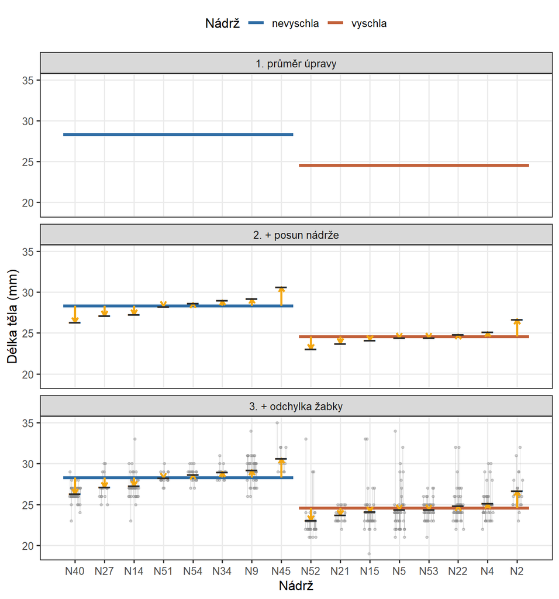

Délky žabek poskládané ze tří vrstev. Nahoře jen průměry obou úprav, uprostřed navíc posun každé nádrže (oranžová šipka od průměru úpravy k průměru nádrže, černá čárka), dole navíc jednotlivé žabky a tenké šedé čáry od každé žabky k průměru její nádrže. Nádrže jsou seřazené podle úpravy a průměrné délky žabek.

Posuny nádrží v prostředním panelu vedou na obě strany, některé nahoru, jiné dolů, a jen málokterý je velký. Můžeme si je představit jako náhodné tahy z rozdělení, které má tvar podobný normálnímu rozděleníSouměrné zvonovité pravděpodobnostní rozdělení určené průměrem a směrodatnou odchylkou; lineární model předpokládá přibližně normální rozdělení residuí. z předchozí lekce. Takovou skupinovou proměnnou, jejíž úrovně chápeme jako výběr z většího souboru možných úrovní, nazýváme náhodný faktorFaktor ve smíšeném modelu, jehož úrovně považujeme za výběr z většího souboru možných úrovní; zajímá nás rozptyl, který přináší, ne konkrétní úrovně.. Posuny jednotlivých skupin od průměru jsou pak **náhodné efekty**.

Dolní panel ukazuje, proč na rozlišení obou vrstev záleží: tenké šedé čáry od žabek k průměru jejich nádrže jsou odchylky žabek, tedy residua vůči nádrži. Lineární modelStatistický model, v němž je průměrná odezva součtem interceptu a prediktorů násobených koeficienty; lineární je v koeficientech, takže nemusí jít jen o přímku., který nádrže nezná, sloučí posun nádrže a odchylku žabky do jediného residuaRozdíl mezi pozorovanou hodnotou odezvy a hodnotou odhadnutou modelem: eᵢ = yᵢ − ŷᵢ.. Model s náhodným faktorem je drží odděleně: ví, které žabky sdílejí stejný posun, protože pocházejí ze stejné nádrže.

## 6.2 Z čeho se skládá délka jedné žabky

Délku každé žabky můžeme rozložit na tři části: průměrSoučet hodnot vydělený jejich počtem; nejběžnější míra polohy (střední hodnoty). její skupiny nádrží, odchylku její nádrže a odchylku žabky od výchozí úrovně nádrže. První dvě části dávají odhadnutou délku žabky. Slovy:

$$\begin{aligned}
\text{odhadnutá délka žabky} = {} & \text{intercept} + \text{rozdíl po vyschnutí} \times \text{vyschla} \\
& + \text{odchylka nádrže}
\end{aligned}$$

Veličina *vyschla* je 1 pro nádrž, která vyschla, a 0 pro nádrž, která nevyschla; rozdíl po vyschnutí se tedy přičte jen u vyschlých nádrží.

Skutečná délka žabky se od odhadnuté liší ještě o residuumRozdíl mezi pozorovanou hodnotou odezvy a hodnotou odhadnutou modelem: eᵢ = yᵢ − ŷᵢ., tedy o odchylku žabky od výchozí úrovně její nádrže.

Podívejme se na jednu konkrétní žabku z nádrže N45. Čísla pocházejí z modelu, který odhadneme v následující části:

Hodnoty pro jednu žabku z nádrže N45.

| Veličina | Hodnota |
| --- | --- |
| nádrž | N45 (nevyschla) |
| naměřená délka žabky | 29 mm |
| intercept (průměr nevyschlých nádrží) | 28,27 mm |
| rozdíl po vyschnutí | -3,73 mm |
| vyschla nádrž? (1 = ano, 0 = ne) | 0 |
| odchylka nádrže N45 | 1,89 mm |

$$\begin{aligned}
\text{odhadnutá délka žabky} &= \text{28,27} + (\text{−3,73}) \times 0 + \text{1,89} \\
&= \text{28,27} + \text{0,00} + \text{1,89} \\
&= \text{30,16}\ \text{mm}
\end{aligned}$$

Žabka měřila 29 mm, její residuum je tedy 29 − 30,16 = -1,16 mm. Nádrž N45 patřila k nádržím s většími žabkami, proto je její odchylka kladná.

Stejný zápis obecně, pro žabku $i$ z nádrže $j$:

$$y_{ij} = \beta_0 + \beta_1 x_{j} + u_j + e_{ij}$$

- $y_{ij}$ je délka žabky $i$ z nádrže $j$;
- $\beta_0$ je intercept, průměrná délka žabek z nevyschlých nádrží (řádek `(Intercept)` ve výstupu R);
- $\beta_1$ je rozdíl vyschlých nádrží oproti nevyschlým (řádek `vyschnutivyschla`);
- $x_{j}$ je 1, pokud nádrž $j$ vyschla, a 0, pokud nevyschla; mění se jen mezi nádržemi, proto má jen index $j$;
- $u_j$ je odchylka nádrže $j$ od průměru její úpravy, tedy posun její **výchozí úrovně**;
- $e_{ij}$ je residuum, odchylka žabky $i$ od výchozí úrovně její nádrže.

Nové je $u_j$. Model neodhaduje každou odchylku nádrže jako samostatný koeficient, jako to dělal pevný faktor. Předpokládá, že odchylky nádrží pocházejí z normálního rozděleníSouměrné zvonovité pravděpodobnostní rozdělení určené průměrem a směrodatnou odchylkou; lineární model předpokládá přibližně normální rozdělení residuí. s průměrem 0 a s neznámou směrodatnou odchylkouOdmocnina rozptylu; vyjadřuje typickou vzdálenost hodnot od průměru ve stejných jednotkách jako původní data., kterou z dat odhadne. Protože odchylka $u_j$ posouvá intercept každé nádrže, nazýváme tento člen **náhodný intercept**. Model, který obsahuje pevné efekty (vyschnutí) i náhodné efekty (nádrže), je **smíšený model**.

## 6.3 Model s náhodným interceptem v R

Funkce `lm()`, se kterou jsme dosud pracovali, náhodné efekty odhadnout neumí. Každý prediktor v ní dostane vlastní koeficienty, takže nádrž by v ní mohla být jen pevným faktorem, a to jsme už viděli, že nefunguje. Pro smíšené modely existuje v R několik balíčků. Všechny dělají v jádru totéž. Liší se tím, jak složité je s nimi pracovat, kolik různých úloh zvládnou a jaké mají nevýhody:

Nejčastější balíčky pro smíšené modely v R.

| Balíček a funkce | Složitost | Všestrannost | Nevýhody |
| --- | --- | --- | --- |
| `nlme`, funkce `lme()` | náhodné efekty se zapisují zvláštním argumentem mimo vzorec | jen pro spojitá měření, jako je délka nebo hmotnost | starší; jiný zápis, než jaký najdete ve většině novějších článků |
| `lme4`, funkce `lmer()` a `glmer()` | náhodné efekty se zapisují přímo do vzorce | spojitá měření i odezvy typu ano/ne a počty, každé jinou funkcí | `lmer()` sama nevypisuje p-hodnoty |
| `glmmTMB`, funkce `glmmTMB()` | stejný zápis jako `lme4` | spojitá měření i odezvy typu ano/ne a počty jednou funkcí; i složitější modely | výstup obsahuje víc částí, než zatím potřebujeme |
| `brms`, funkce `brm()` | jiný, bayesovský přístup ke statistice | velmi všestranný | výpočet trvá dlouho a potřebuje další software; přesahuje rámec kurzu |

V kurzu použijeme `glmmTMB()`, a to z několika důvodů:

- **Stejný zápis vzorce jako `lm()`.** Model zapíšeme stejně jako dosud, jen přidáme náhodný efekt. Zápis `(1 | nadrz)` je navíc stejný jako v balíčku `lme4`, takže mu porozumíte i ve většině vědeckých článků.
- **Jedna funkce pro různé typy odezvy.** V následující lekci budeme modelovat odezvy typu ano/ne a počty. `glmmTMB()` takové modely umí také, včetně náhodných efektů, takže se nemusíme učit novou funkci.
- **Přehledný výstup.** Souhrn modelu obsahuje odhady, standardní chyby i p-hodnoty pevných efektů a směrodatné odchylky náhodných efektů.
- **Spolehlivost.** Balíček je aktivně vyvíjený, rychlý a i složitější modely obvykle odhadne bez potíží.

Funkce `glmmTMB()` umí odhadnout i úplně obyčejný lineární model bez náhodných efektů, a dá přitom stejné výsledky jako `lm()`. Navíc nabízí možnosti, které `lm()` nemá: náhodné efekty, modely pro odezvy typu ano/ne nebo počty a také různou variabilitu residuí v různých skupinách.

Balíček stačí nainstalovat jednou. Následující kód ověří, zda je balíček k dispozici, a pokud chybí, zastaví se se srozumitelnou zprávou.

```r
# Balíček stačí nainstalovat jednou:
# install.packages("glmmTMB")

if (
  !requireNamespace(
    package = "glmmTMB",
    quietly = TRUE
  )) {
  stop(
    "Chybí balíček {glmmTMB}. Nainstalujte ho, viz komentář výše.",
    call. = FALSE
  )
}
```

Ověříme, že `glmmTMB()` bez náhodného efektu odhadne stejný model jako `lm()` se všemi žabkami:

```r
# Stejný model jako mod_vsechny_zabky, jen jinou funkcí
mod_bez_nadrzi <-
  glmmTMB::glmmTMB(
    formula = delka_tela_mm ~ vyschnuti,
    data = data_zabky,
    REML = TRUE
  )

# Koeficienty z lm() a z glmmTMB()
coef(object = mod_vsechny_zabky)
```

```
     (Intercept) vyschnutivyschla
       27.963158        -3.505531
```

```r
glmmTMB::fixef(object = mod_bez_nadrzi)
```

```
Conditional model:
     (Intercept)  vyschnutivyschla
          27.963            -3.506
```

Oba modely odhadly stejný intercept i stejný rozdíl po vyschnutí. Do vzorce stačí přidat náhodný intercept pro nádrž:

```r
# Vyschnutí je pevný efekt, nádrž náhodný intercept
mod_smiseny <-
  glmmTMB::glmmTMB(
    formula = delka_tela_mm ~ vyschnuti + (1 | nadrz),
    data = data_zabky,
    REML = TRUE
  )
```

Zápis vzorce je stejný jako u `lm()`, jen přibyl člen `(1 | nadrz)`. Čteme ho „intercept (`1`) se liší podle (`|`) nádrže”. Argument `REML = TRUE` říká, aby model odhadl rozdíly mezi nádržemi až po zohlednění vlivu vyschnutí. Podobně jsme u směrodatné odchylkyOdmocnina rozptylu; vyjadřuje typickou vzdálenost hodnot od průměru ve stejných jednotkách jako původní data. dělili `n − 1` místo `n`, aby nevyšla systematicky menší.

## 6.4 Jak velký je rozdíl a jak přesně ho známe

```r
# Souhrn smíšeného modelu
summary(object = mod_smiseny)
```

```
 Family: gaussian  ( identity )
Formula:          delka_tela_mm ~ vyschnuti + (1 | nadrz)
Data: data_zabky

      AIC       BIC    logLik -2*log(L)  df.resid
   2043.2    2059.9   -1017.6    2035.2       481

Random effects:

Conditional model:
 Groups   Name        Variance Std.Dev.
 nadrz    (Intercept) 1.310    1.145
 Residual             3.612    1.901
Number of obs: 485, groups:  nadrz, 16

Dispersion estimate for gaussian family (sigma^2): 3.61

Conditional model:
                 Estimate Std. Error z value Pr(>|z|)
(Intercept)       28.2667     0.4336   65.19  < 2e-16 ***
vyschnutivyschla  -3.7280     0.6044   -6.17 6.93e-10 ***
---
Signif. codes:  0 '***' 0.001 '**' 0.01 '*' 0.05 '.' 0.1 ' ' 1
```

```r
# 95% intervaly spolehlivosti pevných efektů (parm = "beta_")
confint(
  object = mod_smiseny,
  parm = "beta_"
)
```

```
                     2.5 %    97.5 % Estimate
(Intercept)      27.416857 29.116476 28.26667
vyschnutivyschla -4.912673 -2.543287 -3.72798
```

Horní část výstupu (`AIC`, `BIC`, `logLik`) zatím nepotřebujeme. Řádek začínající `Number of obs` potvrzuje, že model zná 485 žabek v 16 nádržích. V části `Conditional model` najdeme tabulku pevných efektů. Čte se stejně jako u `lm()`: interceptParametr modelu: odhadnutá hodnota odezvy, když jsou všechny numerické prediktory rovny nule a kategoriální prediktory jsou v referenční skupině; geometricky jde o úsek na ose y. je průměrSoučet hodnot vydělený jejich počtem; nejběžnější míra polohy (střední hodnoty). nevyschlých nádrží a koeficient `vyschnutivyschla` rozdíl vyschlých nádrží. Žabky z vyschlých nádrží jsou podle smíšeného modelu o 3,73 mm menší, se standardní chybouMíra přesnosti odhadu parametru (průměru, sklonu…); odhaduje z jediného výběru, jak moc by se odhady typicky lišily mezi opakovanými výběry stejné velikosti. 0,604 mm a s 95% intervalem spolehlivostiRozsah hodnot vypočtený z dat postupem, který při opakovaných výběrech pokryje skutečnou hodnotu parametru ve zvoleném podílu případů (typicky 95 %). od -4,91 do -2,54 mm.

**Standardní chyba je téměř stejná jako v modelu z průměrů nádrží (0,617 mm), ačkoli model pracuje se všemi 485 žabkami.** Smíšený model tedy „poznal”, že vyschnutí se mění jen mezi 16 nádržemi.

Ve výstupu místo `t value` stojí `z value` (zde -6,17) a p-hodnotaPravděpodobnost, že bychom při platnosti nulové hypotézy pozorovali data alespoň tak extrémní jako naše skutečná data. se počítá z normálního rozděleníSouměrné zvonovité pravděpodobnostní rozdělení určené průměrem a směrodatnou odchylkou; lineární model předpokládá přibližně normální rozdělení residuí. místo t-rozděleníSouměrné rozdělení podobné normálnímu, ale s těžšími chvosty; jeho tvar určují stupně volnosti a používá se pro t-statistiku a intervaly spolehlivosti.. Normální rozdělení odpovídá t-rozdělení s velmi mnoha stupni volnostiPočet nezávislých informací dostupných pro odhad parametru; počet pozorování minus počet odhadovaných parametrů.. Při 16 nádržích je proto interval smíšeného modelu o něco užší a p-hodnota menší, než by byly při přesnějším výpočtu. Na závěru o vyschnutí to nic nemění.

## 6.5 Jak moc se liší nádrže a jak moc žabky v jedné nádrži

V části `Random effects` výstupu jsou dva řádky:

- `nadrz (Intercept)`: směrodatná odchylkaOdmocnina rozptylu; vyjadřuje typickou vzdálenost hodnot od průměru ve stejných jednotkách jako původní data. výchozích úrovní nádrží, 1,14 mm. Typická nádrž se od průměruSoučet hodnot vydělený jejich počtem; nejběžnější míra polohy (střední hodnoty). své úpravy liší asi o 1,1 mm.
- `Residual`: směrodatná odchylka residuíRozdíl mezi pozorovanou hodnotou odezvy a hodnotou odhadnutou modelem: eᵢ = yᵢ − ŷᵢ., 1,90 mm. Typická žabka se od výchozí úrovně své nádrže liší asi o 1,9 mm.

Výchozí úrovně nádrží si lze nakreslit i bez dalších balíčků. Následující kód vezme žabky seřazené podle průměru jejich nádrže, obarví je podle úpravy, pro každou nádrž spočítá její výchozí úroveň (odhad pro danou úpravu plus odchylka nádrže z `glmmTMB::ranef()`) a vedle ní vykreslí odhad jen z pevných efektů pro obě úpravy.

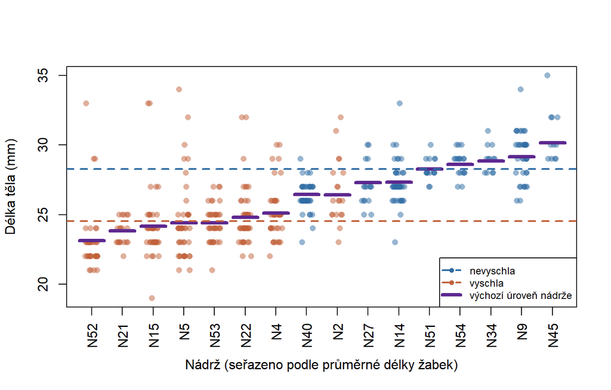

Smíšený model v datech. Body jsou žabky seřazené podle nádrží a obarvené podle úpravy, nevyschlé nádrže modře a vyschlé cihlově červeně. Fialové úsečky jsou výchozí úrovně nádrží z modelu, přerušované čáry odhad jen z pevných efektů pro nevyschlé a vyschlé nádrže.

```r
set.seed(900723)

# Barvy použité v grafu
barva_nevyschla <- "#2E6CA4"
barva_vyschla <- "#C2613A"
barva_nadrze <- "#5D2890"

# Odhady pevných efektů a odchylky nádrží z modelu
vec_pevne <- glmmTMB::fixef(object = mod_smiseny)$cond
mat_odchylky <- glmmTMB::ranef(object = mod_smiseny)$cond$nadrz

# Jeden řádek pro každou nádrž: úprava a výchozí úroveň z modelu
data_nadrze_model <- unique(x = data_zabky[, c("nadrz", "vyschnuti")])
data_nadrze_model$uroven <-
  vec_pevne["(Intercept)"] +
  vec_pevne["vyschnutivyschla"] * (data_nadrze_model$vyschnuti == "vyschla") +
  mat_odchylky[as.character(x = data_nadrze_model$nadrz), "(Intercept)"]

# Nádrže seřazené podle průměrné délky žabek
vec_prumery_nadrzi <-
  tapply(
    X = data_zabky$delka_tela_mm,
    INDEX = data_zabky$nadrz,
    FUN = mean
  )
vec_poradi_nadrzi <- names(x = sort(x = vec_prumery_nadrzi))

# Pozice nádrže na vodorovné ose pro každou žabku a pro každou nádrž
vec_pozice_zabek <-
  match(
    x = as.character(x = data_zabky$nadrz),
    table = vec_poradi_nadrzi
  )
vec_pozice_nadrzi <-
  match(
    x = as.character(x = data_nadrze_model$nadrz),
    table = vec_poradi_nadrzi
  )

# Barva každé žabky podle úpravy její nádrže (poloprůhledná)
vec_barvy_zabek <-
  adjustcolor(
    col = ifelse(
      test = data_zabky$vyschnuti == "vyschla",
      yes = barva_vyschla,
      no = barva_nevyschla
    ),
    alpha.f = 0.5
  )

# Žabky s malým náhodným posunem do stran, aby se body nepřekrývaly
plot(
  x = jitter(
    x = vec_pozice_zabek,
    amount = 0.2
  ),
  y = data_zabky$delka_tela_mm,
  xaxt = "n",
  pch = 16,
  col = vec_barvy_zabek,
  xlab = "Nádrž (seřazeno podle průměrné délky žabek)",
  ylab = "Délka těla (mm)"
)
axis(
  side = 1,
  at = seq_along(along.with = vec_poradi_nadrzi),
  labels = vec_poradi_nadrzi,
  las = 2
)

# Výchozí úroveň každé nádrže jako krátká fialová úsečka
segments(
  x0 = vec_pozice_nadrzi - 0.4,
  x1 = vec_pozice_nadrzi + 0.4,
  y0 = data_nadrze_model$uroven,
  y1 = data_nadrze_model$uroven,
  col = barva_nadrze,
  lwd = 4
)

# Odhad jen z pevných efektů pro obě úpravy
abline(
  h = vec_pevne["(Intercept)"],
  col = barva_nevyschla,
  lty = 2,
  lwd = 2
)
abline(
  h = vec_pevne["(Intercept)"] + vec_pevne["vyschnutivyschla"],
  col = barva_vyschla,
  lty = 2,
  lwd = 2
)

# Legenda: barvy úprav a výchozí úroveň nádrže
legend(
  x = "bottomright",
  legend = c("nevyschla", "vyschla", "výchozí úroveň nádrže"),
  col = c(barva_nevyschla, barva_vyschla, barva_nadrze),
  pch = c(16, 16, NA),
  lty = c(2, 2, 1),
  lwd = c(2, 2, 4),
  cex = 0.75,
  bg = "white"
)
```

Přerušované čáry ukazují odhad rozdílu po vyschnutí, zatímco fialové úsečky se kolem čáry své úpravy rozcházejí na obě strany: právě tento rozptyl výchozích úrovní nádrží měří řádek `nadrz (Intercept)`.

**QuestionKde je víc variability?**

Liší se víc nádrže mezi sebou, nebo žabky uvnitř jedné nádrže?

Žabky uvnitř nádrže se liší víc než nádrže mezi sebou. Rozdíly mezi nádržemi přesto nejsou zanedbatelné. Když obě směrodatné odchylky umocníme na druhou, dostaneme rozptylySoučet čtverců odchylek od průměru dělený n − 1; míra variability dat. Odmocnina rozptylu je směrodatná odchylka., které se dají sčítat:

$$\text{podíl variability mezi nádržemi} = \frac{\text{rozptyl mezi nádržemi}}{\text{rozptyl mezi nádržemi} + \text{rozptyl mezi žabkami v nádrži}}$$

$$\frac{\text{1,14}^2}{\text{1,14}^2 + \text{1,90}^2}
= \frac{\text{1,31}}{\text{1,31} + \text{3,61}}
= \text{0,27}$$

Přibližně 27 % variabilityObecný termín pro rozsah, v němž se hodnoty proměnné liší od sebe navzájem; kvantifikuje se pomocí rozptylu, SD, IQR nebo rozsahu. v délce žabek, která zbývá po zohlednění vyschnutí, připadá na rozdíly mezi nádržemi a zbytek na rozdíly mezi žabkami jedné nádrže. Právě tato podobnost žabek z jedné nádrže způsobila, že model se všemi žabkami tak silně podhodnotil nejistotuRozsah, v němž nevíme přesnou hodnotu parametru kvůli omezenému výběru a výběrové variabilitě; kvantifikuje se pomocí standardních chyb a intervalů spolehlivosti..

## 6.6 Kolik nezávislé informace je v 16 nádržích?

Představte si, že stejný pokus navrhujete od začátku a máte dvě možnosti. Můžete postavit mnoho malých nádrží a v každé nechat vyrůst jedinou žabku: každá žabka tak má vlastní vodu i vlastní potravu a je na ostatních nezávislá. Nebo postavíte méně větších nádrží a v každé vyroste víc žabek, jako v tomto pokusu. Pomiňme, že osamělý pulec by rostl jinak než pulec mezi ostatními; jde jen o to, kolik nezávislé informace o vyschnutí každý návrh přinese.

Kolika nádržím s jedinou žabkou tedy odpovídá našich 16 nádrží, ve kterých vyrostlo průměrně asi 30 žabek? Odpověď dává podíl variabilityObecný termín pro rozsah, v němž se hodnoty proměnné liší od sebe navzájem; kvantifikuje se pomocí rozptylu, SD, IQR nebo rozsahu. mezi nádržemi z předchozí části, protože říká, jak moc se žabky z jedné nádrže podobají.

**QuestionOdhadněte předem**

Kdybychom v každé z 16 nádrží změřili 100 žabek, tedy celkem 1600, kolika nádržím s jedinou žabkou by to zhruba odpovídalo?

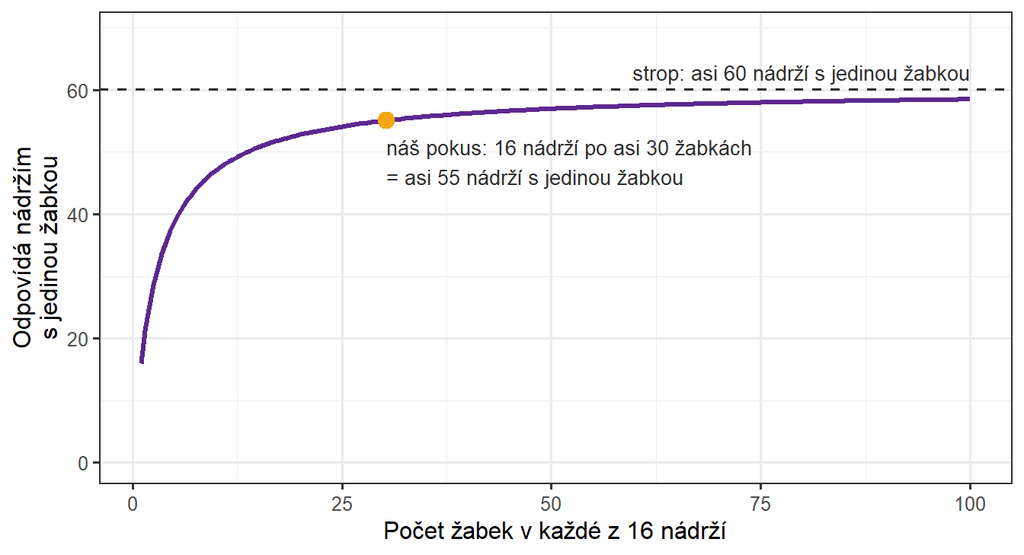

Kolika nádržím s jedinou žabkou odpovídá 16 nádrží podle toho, kolik žabek vyroste v každé z nich. Oranžový bod je náš pokus, přerušovaná čára strop, ke kterému se křivka blíží.

Kdyby v každé z 16 nádrží vyrostla jediná žabka, měli bychom 16 nezávislých žabek. V našem pokusu vyrostlo v nádrži v průměruSoučet hodnot vydělený jejich počtem; nejběžnější míra polohy (střední hodnoty). asi 30 žabek a celkem 485 žabek přináší o vyschnutí asi tolik informace jako **55 nádrží s jedinou žabkou**. To je víc než 16, protože žabky z jedné nádrže si nejsou úplně stejné, ale mnohem méně než 485. Kdybychom v každé nádrži změřili 100 žabek, odpovídalo by to asi 58 nádržím s jedinou žabkou, tedy jen o málo víc. S 16 nádržemi se křivka zastaví u stropu asi 60 nádrží s jedinou žabkou, ať v nádržích změříme žabek kolik chceme. Víc informace o vyschnutí může přinést jen víc nádrží.

Odhad souhlasí s tím, co ukázaly modely. Když 485 žabek vydá jen za asi 55 nezávislých, tedy za asi 8,8krát méně, standardní chybaMíra přesnosti odhadu parametru (průměru, sklonu…); odhaduje z jediného výběru, jak moc by se odhady typicky lišily mezi opakovanými výběry stejné velikosti. vyjde zhruba 3,0krát větší. Smíšený model dal standardní chybu 3,0krát větší než model, který počítá každou žabku zvlášť.

**PoznámkaDoplňující: jak se počet nádrží s jedinou žabkou odhaduje**

Slovy: počet žabek vydělíme číslem, které roste s počtem žabek v nádrži a s podílem variability mezi nádržemi.

$$\text{počet nádrží s jedinou žabkou} = \frac{\text{počet žabek}}{1 + (\text{počet žabek v nádrži} - 1) \times \text{podíl variability mezi nádržemi}}$$

S čísly z našeho pokusu (počet žabek v nádrži je průměr přes nádrže):

$$\begin{aligned}
\text{počet nádrží s jedinou žabkou} &= \frac{485}{1 + (\text{30,3} - 1) \times \text{0,266}} \\
&= \frac{485}{\text{8,80}} \\
&= \text{55,1}
\end{aligned}$$

Když žabek v nádrži přibývá, rostou čitatel i jmenovatel úměrně jejich počtu a výsledek se blíží stropu:

$$\text{strop} = \frac{\text{počet nádrží}}{\text{podíl variability mezi nádržemi}}$$

$$\text{strop} = \frac{16}{\text{0,266}} = \text{60,1}$$

Obecně:

$$n_{\text{ef}} = \frac{n}{1 + (m - 1)\,\rho}$$

- $n_{\text{ef}}$ je odhadnutý počet nezávislých pozorováníJeden zaznamenaný případ v datech, který obsahuje hodnoty jedné nebo více proměnných., tady nádrží s jedinou žabkou;
- $n$ je počet všech pozorování (žabek);
- $m$ je počet pozorování v jedné skupině (žabek v nádrži);
- $\rho$ je podíl variability mezi skupinami, který jsme spočítali ze dvou směrodatných odchylekOdmocnina rozptylu; vyjadřuje typickou vzdálenost hodnot od průměru ve stejných jednotkách jako původní data. smíšeného modelu.

Když $\rho = 0$, jsou si žabky z jedné nádrže podobné stejně jako žabky z různých nádrží a každá žabka má stejnou cenu jako nádrž s jedinou žabkou. Když $\rho = 1$, jsou všechny žabky jedné nádrže stejné a celá nádrž vydá jen za jednu nádrž s jedinou žabkou. Protože se počty žabek v nádržích liší, je výsledek jen přibližný.

## 6.7 Kde leží odhadnuté výchozí úrovně nádrží?

Smíšený model odhadl pro každou nádrž její výchozí úroveň: průměrSoučet hodnot vydělený jejich počtem; nejběžnější míra polohy (střední hodnoty). úpravy plus posun nádrže. Leží tato úroveň přesně na průměru žabek z nádrže? Podívejme se na nejmenší nádrž (11 žabek), jednu středně velkou (19) a největší (47).

**QuestionOdhadněte předem**

Kam podle vás model umístí výchozí úroveň malé nádrže a kam velké: na průměr žabek z nádrže, na průměr úpravy, nebo někam mezi?

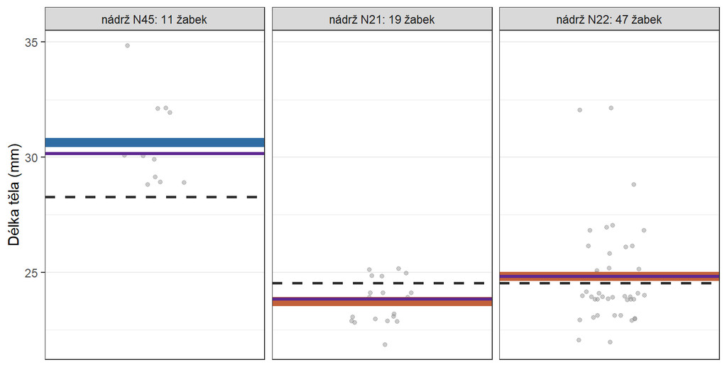

Tři nádrže různé velikosti. Šedé body jsou žabky, černá přerušovaná čára průměr úpravy, plná čára v barvě úpravy průměr žabek z nádrže a fialová čára výchozí úroveň odhadnutá smíšeným modelem.

Fialová výchozí úroveň leží vždy mezi průměrem žabek z nádrže a průměrem úpravy. U nejmenší nádrže se od průměru nádrže znatelně posunula směrem k průměru úpravy, u největší s průměrem nádrže téměř splývá. Průměr z mála žabek je nejistý, a model mu proto věří méně; průměr ze 40 a více žabek je přesný a model ho skoro nemění.

Stejný obraz pro všech 16 nádrží:

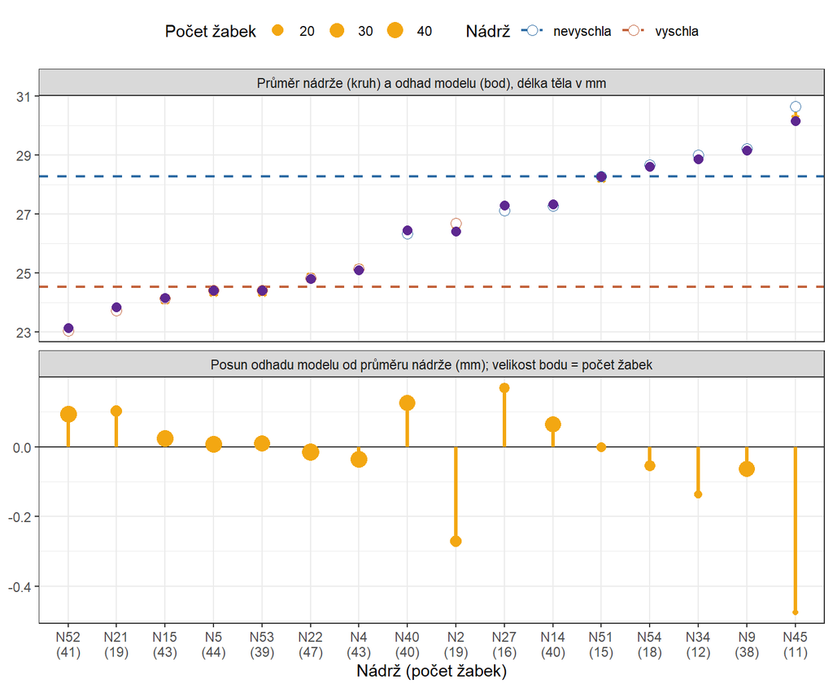

Horní panel: pro každou nádrž průměr jejích žabek (prázdný kruh) a výchozí úroveň odhadnutá smíšeným modelem (fialový bod). Oranžová šipka vede od průměru nádrže k odhadu modelu. Dolní panel: stejný posun v milimetrech, velikost bodu odpovídá počtu žabek. Přerušované čáry v barvě úpravy ukazují odhad modelu pro nevyschlé a vyschlé nádrže. Nádrže jsou seřazené podle průměrné délky žabek, pod názvem nádrže je počet žabek.

Výchozí úrovně nádrží ze smíšeného modelu leží blízko průměrů nádrží, ale o kousek blíž k průměru své úpravy. Nejvíc se posunula nádrž N45, ze které vylezlo jen 11 žabek, a to o 0,47 mm. Nádrže se 40 a více žabkami se posunuly nanejvýš o 0,13 mm. Model tak odhaduje výchozí úroveň malé nádrže opatrněji: z mála žabek nelze její průměr určit tak přesně, a model si proto „půjčí” část informace od ostatních nádrží.

## 6.8 Co prozradí residua a výchozí úrovně nádrží

Ze čtyř podmínek, které musí být u lineárního modeluStatistický model, v němž je průměrná odezva součtem interceptu a prediktorů násobených koeficienty; lineární je v koeficientech, takže nemusí jít jen o přímku. rozumné, selhala u modelu se všemi žabkami nezávislost pozorováníJeden zaznamenaný případ v datech, který obsahuje hodnoty jedné nebo více proměnných.. Smíšený model s podobností žabek z jedné nádrže počítá: ví, které žabky sdílejí nádrž, a nejistotuRozsah, v němž nevíme přesnou hodnotu parametru kvůli omezenému výběru a výběrové variabilitě; kvantifikuje se pomocí standardních chyb a intervalů spolehlivosti. rozdílu po vyschnutí posuzuje podle počtu nádrží. Zbývá zkontrolovat tvar residuíRozdíl mezi pozorovanou hodnotou odezvy a hodnotou odhadnutou modelem: eᵢ = yᵢ − ŷᵢ., podobně jako v předchozí lekci, a rozptýlení residuí kolem odhadů. U smíšeného modelu máme navíc odhadnuté odchylky nádrží, o kterých model předpokládá, že pocházejí z normálního rozděleníSouměrné zvonovité pravděpodobnostní rozdělení určené průměrem a směrodatnou odchylkou; lineární model předpokládá přibližně normální rozdělení residuí..

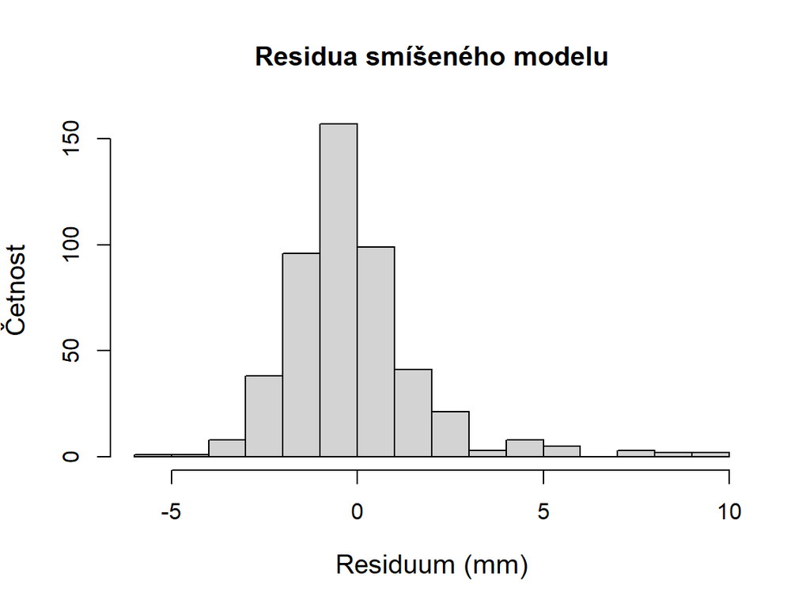

```r
# Residua: odchylky žabek od výchozí úrovně jejich nádrže
vec_residua <-
  residuals(object = mod_smiseny)

# Histogram residuí
hist(
  x = vec_residua,
  breaks = 20,
  main = "Residua smíšeného modelu",
  xlab = "Residuum (mm)",
  ylab = "Četnost",
  cex.lab = 1.2
)
```

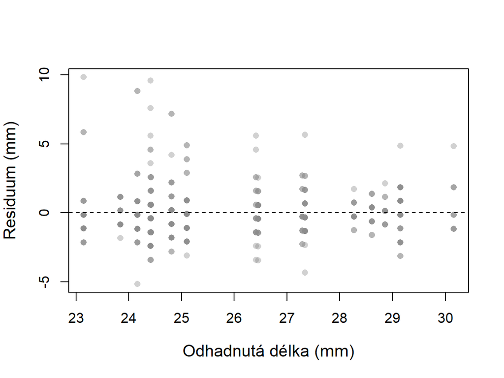

```r
# Residua proti odhadnutým hodnotám (včetně výchozí úrovně nádrže)
plot(
  x = fitted(object = mod_smiseny),
  y = vec_residua,
  xlab = "Odhadnutá délka (mm)",
  ylab = "Residuum (mm)",
  pch = 16,
  col = "#8C8C8C66",
  cex.lab = 1.2
)

abline(
  h = 0,
  lty = 2
)
```

V modelu se všemi žabkami tvořila residua jen dva sloupce. Ve smíšeném modelu má každá nádrž vlastní odhad, a body se proto rozprostřely po celé ose odhadnutých hodnot. Rozptýlení residuí je podobné u malých i velkých odhadů.

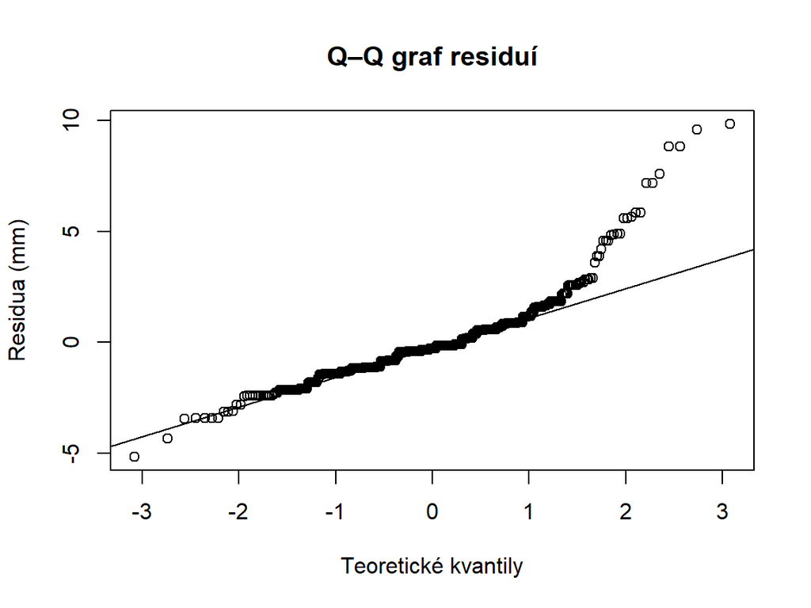

```r
# Q–Q graf residuí
qqnorm(
  y = vec_residua,
  main = "Q–Q graf residuí",
  xlab = "Teoretické kvantily",
  ylab = "Residua (mm)"
)

qqline(y = vec_residua)
```

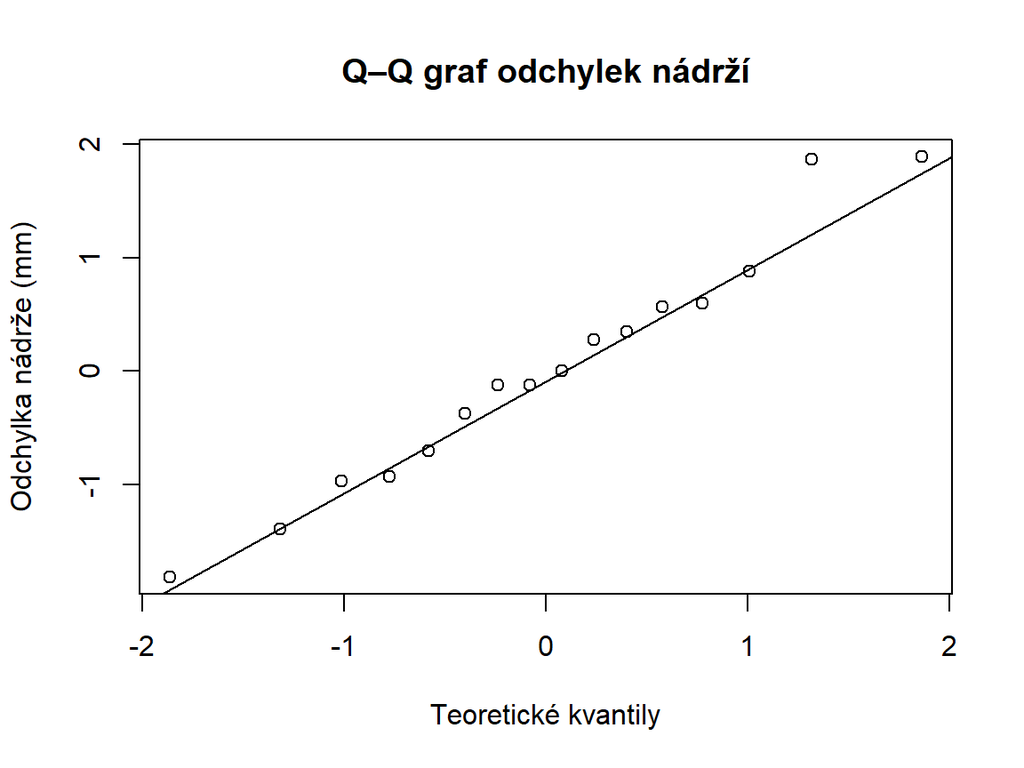

```r
# Odhadnuté odchylky (posuny výchozích úrovní) nádrží
vec_odchylky_nadrzi <-
  glmmTMB::ranef(object = mod_smiseny)$cond$nadrz[, 1]

# Q–Q graf odchylek nádrží
qqnorm(
  y = vec_odchylky_nadrzi,
  main = "Q–Q graf odchylek nádrží",
  xlab = "Teoretické kvantily",
  ylab = "Odchylka nádrže (mm)"
)

qqline(y = vec_odchylky_nadrzi)
```

Tvar residuí ale normálnímu rozdělení neodpovídá. HistogramGraf zobrazující rozdělení hodnot numerické proměnné: hodnoty jsou rozděleny do sousedních intervalů (košů), výška sloupce udává četnost v daném koši. má dlouhý chvost vpravo a na Q–Q grafuGraf, který porovnává seřazené hodnoty (typicky residua) s kvantily očekávanými u zvoleného rozdělení, nejčastěji normálního. se body vpravo nahoře zřetelně odklánějí od přímky. Residua jsou pravostranně šikmáNesouměrnost rozdělení: u pravostranně šikmého rozdělení se hodnoty táhnou dlouhým chvostem vpravo k vysokým hodnotám a průměr bývá větší než medián.: koeficient šikmosti z předchozí lekce vychází 1,8, zatímco u souměrného rozdělení by byl blízko nuly.

Dlouhý chvost tvoří několik žabek, které byly mnohem větší, než odpovídá jejich nádrži. Residuum větší než 3,8 mm, tedy víc než 2násobek typické odchylky žabky od výchozí úrovně nádrže, má 22 žabek a 21 z nich vylezlo z vody později než polovina žabek ze stejné nádrže. Jsou to tedy hlavně pozdní, velké žabky. U dne metamorfózy jsme viděli proč: uvnitř nádrže jsou žabky, které zůstaly ve vodě déle, větší.

Stojí závěr o vyschnutí na tvaru residuí jednotlivých žabek? Model z průměrůSoučet hodnot vydělený jejich počtem; nejběžnější míra polohy (střední hodnoty). nádrží se o něj neopírá: jeho pozorováními jsou průměry nádrží a průměr z mnoha žabek má tvar mnohem bližší normálnímu rozdělení než jednotlivé žabky. Tento model dal rozdíl -3,76 mm, prakticky stejný jako -3,73 mm ze smíšeného modelu, a podobnou standardní chybuMíra přesnosti odhadu parametru (průměru, sklonu…); odhaduje z jediného výběru, jak moc by se odhady typicky lišily mezi opakovanými výběry stejné velikosti.. **Závěr o vyschnutí proto na šikmých residuích nestojí.**

Odhadnuté odchylky nádrží leží přibližně na přímce. Je jich ovšem jen 16, takže jejich tvar posuzujeme jen hrubě.

**TipDoplňující: platí totéž pro suchou hmotnost?**

Suchá hmotnost dává stejný obraz. Podle smíšeného modelu vážily žabky z vyschlých nádrží v sušině o 0,096 g méně, se standardní chybou 0,023 g. Model se všemi žabkami by uvedl standardní chybu 0,0077 g, model z průměrů nádrží 0,024 g. Residua hmotnosti jsou ještě šikmější než residua délky, protože hmotnost roste s délkou zhruba třetí mocninou.

## 6.9 Jakou část variability zachytil model se všemi žabkami?

U lineárních modelů jsme se ptali, jakou část variabilityObecný termín pro rozsah, v němž se hodnoty proměnné liší od sebe navzájem; kvantifikuje se pomocí rozptylu, SD, IQR nebo rozsahu. odezvy model zachytí. Odpověď dával koeficient determinace R²Podíl variability odezvy zachycený modelem: R² = 1 − RSS / celkový součet čtverců (0 = model nezachytí nic navíc oproti průměru, 1 = zachytí vše).. Stejnou otázku si položíme i u smíšeného modelu. Abychom ji mohli zodpovědět, připomeneme si na modelu, který počítá každou žabku zvlášť, odkud se R² bere.

R² se počítá ze dvou součtů čtverců:

- Celkový součet čtvercůSoučet druhých mocnin odchylek pozorovaných hodnot odezvy od jejich průměru; popisuje celkovou variabilitu odezvy před použitím prediktorů. měří, jak moc se délky všech žabek liší od jejich společného průměru. Popisuje variabilitu dřív, než použijeme jakýkoli prediktor.
- Součet čtverců residuí (RSS)Součet druhých mocnin všech residuí (RSS); vyjadřuje celkovou čtvercovou odchylku pozorovaných hodnot od hodnot odhadnutých modelem. měří, kolik z těchto rozdílů zůstane, když každé žabce přiřadíme odhad modelu, tedy průměr její úpravy.

Zachycený podíl variability je ta část celkového součtu čtverců, která po přidání prediktoru z residuí zmizela:

$$R^2 = 1 - \frac{\text{součet čtverců residuí}}{\text{celkový součet čtverců}}$$

Pro model, který počítá každou žabku zvlášť:

$$R^2 = 1 - \frac{\text{2 208,0}}{\text{3 628,1}} = \text{0,39}$$

Vyšlo stejné číslo jako `Multiple R-squared` ve výstupu `summary()`. Stejnou úvahu jsme poznali u analýzy rozptyluStatistický test porovnávající průměry tří a více skupin zároveň; testuje, zda se alespoň jedna skupina průměrem liší od ostatních.: celkový součet čtverců se rozdělil na část **mezi skupinami**, kterou zachytí rozdílné průměry skupin, a na část **uvnitř skupin**, která zbude jako residua. V modelu se všemi žabkami jsou skupinami vyschlé a nevyschlé nádrže. Rozdíly mezi nádržemi se stejnou úpravou model nezná, takže skončily v residuích spolu s rozdíly mezi žabkami.

## 6.10 Koeficient determinace jako podíl rozptylu

Součty čtverců rostou s počtem žabek. Když je vydělíme počtem žabek bez jedné, dostaneme rozptylySoučet čtverců odchylek od průměru dělený n − 1; míra variability dat. Odmocnina rozptylu je směrodatná odchylka.. Rozptyl je druhá mocnina směrodatné odchylkyOdmocnina rozptylu; vyjadřuje typickou vzdálenost hodnot od průměru ve stejných jednotkách jako původní data. a má tu výhodu, že se rozptyly nezávislých částí dají sčítat. Rozptyl naměřených délek se rozpadne na dvě části:

$$\text{rozptyl délek} = \text{rozptyl zachycený vyschnutím} + \text{rozptyl residuí}$$

Rozptyl zachycený vyschnutím je rozptyl odhadnutých hodnot modelu. Každá žabka v nich dostane průměr své úpravy, takže tato část obsahuje jen rozdíl mezi vyschlými a nevyschlými nádržemi.

Rozdělení rozptylu délek v modelu, který počítá každou žabku zvlášť.

| Část variability | Rozptyl (mm²) |
| --- | --- |
| zachycená vyschnutím (odhadnuté hodnoty) | 2,93 |
| residua (rozdíly mezi žabkami se stejnou úpravou) | 4,56 |
| celkem (naměřené délky) | 7,50 |

$$\text{7,50} = \text{2,93} + \text{4,56}$$

Podíl první části na celku je opět R²:

$$R^2 = \frac{\text{rozptyl zachycený vyschnutím}}{\text{rozptyl délek}} = \frac{\text{2,93}}{\text{7,50}} = \text{0,39}$$

Obě cesty vedou ke stejnému číslu. Pohled přes rozptyly se hodí pro smíšený model, protože ten ve výstupu neukazuje součty čtverců, ale směrodatné odchylky, ze kterých rozptyly snadno dostaneme.

## 6.11 Tři části variability v délce žabek

V modelu se všemi žabkami tvořila residua jednu velkou část. Smíšený model z ní oddělil rozdíly mezi nádržemi. Z části `Random effects` jsme už přečetli rozptyl mezi nádržemi a rozptyl mezi žabkami v jedné nádrži. Spolu s rozptylem zachyceným vyschnutím tak máme tři části variabilityObecný termín pro rozsah, v němž se hodnoty proměnné liší od sebe navzájem; kvantifikuje se pomocí rozptylu, SD, IQR nebo rozsahu.:

$$\begin{aligned}
\text{celkový rozptyl} &= \text{rozptyl zachycený vyschnutím} + \text{rozptyl mezi nádržemi} \\
&\quad + \text{rozptyl mezi žabkami v nádrži}
\end{aligned}$$

**QuestionOdhadněte předem**

Na kterou ze tří částí podle vás připadne největší díl variability v délce žabek: na vyschnutí, na rozdíly mezi nádržemi, nebo na rozdíly mezi žabkami jedné nádrže?

Rozdělení rozptylu délek ve smíšeném modelu.

| Část variability | Rozptyl (mm²) | Podíl |
| --- | --- | --- |
| zachycená vyschnutím | 2,93 | 37 % |
| rozdíly mezi nádržemi | 1,31 | 17 % |
| rozdíly mezi žabkami v nádrži | 3,61 | 46 % |
| celkem | 7,86 | 100 % |

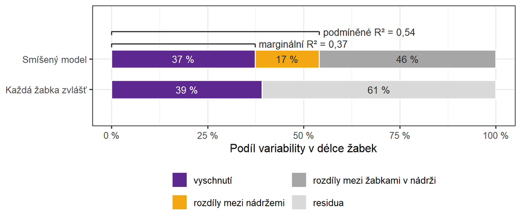

Rozdělení variability v délce žabek. Dolní pruh: model, který počítá každou žabku zvlášť. Horní pruh: smíšený model, ve kterém se residua rozdělila na rozdíly mezi nádržemi a rozdíly mezi žabkami jedné nádrže. Závorky nad smíšeným modelem ukazují, kterou část zahrnuje marginální a podmíněné R².

Největší část variability připadá na rozdíly mezi žabkami jedné nádrže. Vyschnutí zachytí o něco méně a rozdíly mezi nádržemi tvoří menší, ale zřetelnou část. Podíl vyschnutí je v obou modelech podobný: smíšený model vyschnutí nic neubral, jen rozdělil residua na dvě části.

Součet tří částí (7,86 mm²) je o něco větší než rozptyl naměřených délek (7,50 mm²). Smíšený model totiž rozptyl mezi nádržemi nepočítá jen z našich 16 nádrží, ale odhaduje ho pro celý soubor nádrží, ze kterého naše nádrže pocházejí. Proto vyšel podíl vyschnutí o kousek menší než R² modelu se všemi žabkami.

**UpozorněníPozor: dva různé podíly nádrží**

V části o rozdílech mezi nádržemi a mezi žabkami jsme spočítali, že na nádrže připadá asi 27 % variability. Tady vyšlo asi 17 %. Obě čísla jsou správná, ale mají jiný jmenovatel. Dřívější podíl se počítal jen z variability, která zbyla po zohlednění vyschnutí. Tady počítáme z celé variability v délce žabek, včetně části zachycené vyschnutím.

## 6.12 Marginální a podmíněné R²

Ze tří částí variability můžeme spočítat dvě různá R²Podíl variability odezvy zachycený modelem: R² = 1 − RSS / celkový součet čtverců (0 = model nezachytí nic navíc oproti průměru, 1 = zachytí vše).. Liší se tím, které části počítáme jako zachycené modelem:

- **Marginální R²** počítá jako zachycenou jen část připadající na pevné efekty, tady na vyschnutí. Odpovídá na otázku: kolik variability zachytí prediktor, který nás zajímá?
- **Podmíněné R²** počítá jako zachycené pevné i náhodné efekty, tady vyschnutí i rozdíly mezi nádržemi. Odpovídá na otázku: kolik variability zachytí celý model, když zná i výchozí úrovně nádrží?

Slovy:

$$\begin{aligned}
\text{marginální } R^2 &= \frac{\text{rozptyl zachycený vyschnutím}}{\text{celkový rozptyl}} \\
\text{podmíněné } R^2 &= \frac{\text{rozptyl zachycený vyschnutím} + \text{rozptyl mezi nádržemi}}{\text{celkový rozptyl}}
\end{aligned}$$

S čísly z našeho modelu:

$$\begin{aligned}
\text{marginální } R^2 &= \frac{\text{2,93}}{\text{2,93} + \text{1,31} + \text{3,61}} = \text{0,37} \\
\text{podmíněné } R^2 &= \frac{\text{2,93} + \text{1,31}}{\text{2,93} + \text{1,31} + \text{3,61}} = \text{0,54}
\end{aligned}$$

Obecně, se symboly:

$$R^2_{m} = \frac{\sigma^2_f}{\sigma^2_f + \sigma^2_u + \sigma^2_e}, \qquad R^2_{c} = \frac{\sigma^2_f + \sigma^2_u}{\sigma^2_f + \sigma^2_u + \sigma^2_e}$$

- $R^2_{m}$ je marginální a $R^2_{c}$ podmíněné R² (z anglického *marginal* a *conditional*);
- $\sigma^2_f$ je rozptyl odhadů pevné části modelu, tady rozdílu mezi vyschlými a nevyschlými nádržemi;
- $\sigma^2_u$ je rozptyl výchozích úrovní nádrží, tedy druhá mocnina směrodatné odchylky v řádku `nadrz (Intercept)`;
- $\sigma^2_e$ je rozptyl residuí, tedy druhá mocnina směrodatné odchylky v řádku `Residual`.

Vyschnutí zachytí asi 37 % variability v délce žabek. Rozdíly mezi nádržemi přidají dalších asi 17 %, takže celý model zachytí asi 54 %. Zbylých 46 % tvoří rozdíly mezi žabkami jedné nádrže, které model nevysvětlí. Marginální a podmíněné R² zavedli S. Nakagawa a H. Schielzeth (2013).

**PoznámkaDoplňující: výpočet R² smíšeného modelu v R**

Tři rozptyly můžeme z modelu získat přímo:

```r
# Rozptyl odhadů pevné části (jen vyschnutí, bez nádrží)
rozptyl_vyschnuti <-
  var(predict(object = mod_smiseny, re.form = NA))

# Rozptyl výchozích úrovní nádrží
rozptyl_mezi_nadrzemi <-
  glmmTMB::VarCorr(x = mod_smiseny)$cond$nadrz[1, 1]

# Rozptyl residuí
rozptyl_v_nadrzi <-
  sigma(object = mod_smiseny)^2

rozptyl_celkovy <-
  rozptyl_vyschnuti + rozptyl_mezi_nadrzemi + rozptyl_v_nadrzi

# Marginální a podmíněné R²
rozptyl_vyschnuti / rozptyl_celkovy
```

```
[1] 0.3734719
```

```r
(rozptyl_vyschnuti + rozptyl_mezi_nadrzemi) / rozptyl_celkovy
```

```
[1] 0.540255
```

Argument `re.form = NA` říká funkci `predict()`, aby počítala odhady bez výchozích úrovní nádrží. Pro složitější modely zvládne tento výpočet například funkce `r2()` z balíčku `performance`.

## 6.13 Co R² smíšeného modelu říká a co ne

Pro R² smíšeného modelu platí stejná omezení jako pro R² lineárního modelu. Popisuje data, na kterých byl model odhadnut. Neříká, jestli jsou splněny předpoklady modelu, ty jsme kontrolovali na residuích. A neříká ani, jak přesně model odhadne délku jedné konkrétní žabky. U smíšeného modelu k tomu přibývají tři věci:

- **Vysoké podmíněné R² neznamená, že vyschnutí je důležité.** Velkou část podmíněného R² mohou tvořit rozdíly mezi nádržemi, které mají jiné příčiny. O vyschnutí vypovídá marginální R² a hlavně odhad rozdílu s jeho intervalem spolehlivostiRozsah hodnot vypočtený z dat postupem, který při opakovaných výběrech pokryje skutečnou hodnotu parametru ve zvoleném podílu případů (typicky 95 %)..
- **Rozdíly mezi nádržemi model nevysvětluje, jen je popisuje.** Víme, že se nádrže liší, ale ne proč. Kdybychom v každé nádrži změřili třeba teplotu vody nebo hustotu pulců, mohli bychom je přidat jako prediktory a část rozptylu mezi nádržemi by se přesunula do zachycené části.
- **R² smíšeného modelu nelze srovnávat s R² modelu z průměrů nádrží.** Model z průměrů nádrží má R² 0,73, ale jeho odezvou je průměr nádrže, ne délka žabky. Průměry kolísají mnohem méně než jednotlivé žabky, proto je podíl zachycené variability vyšší. R² se dá porovnávat jen mezi modely se stejnou odezvou a stejnými pozorováními.

## 6.14 Čtyři způsoby, jak odpovědět na stejnou otázku

Čtyři odpovědi na otázku, o kolik jsou menší žabky z vyschlých nádrží.

| Postup | Nezávislé jednotky | Rozdíl (mm) | SE (mm) |
| --- | --- | --- | --- |
| každá žabka zvlášť | 485 žabek | -3,51 | 0,199 |
| průměry nádrží | 16 nádrží | -3,76 | 0,617 |
| nádrž jako pevný faktor | — | nelze | — |
| náhodný intercept | 16 nádrží | -3,73 | 0,604 |

Všechny postupy kromě pevného faktoruFaktor v modelu, jehož konkrétní úrovně jsou pro analýzu relevantní a vyčerpávají (nebo reprezentují) všechny zájmové kategorie. odhadly podobný rozdíl. Liší se v tom, kolik nezávislé informace si myslí, že mají. Model se všemi žabkami nejistotuRozsah, v němž nevíme přesnou hodnotu parametru kvůli omezenému výběru a výběrové variabilitě; kvantifikuje se pomocí standardních chyb a intervalů spolehlivosti. podhodnotil, model z průměrůSoučet hodnot vydělený jejich počtem; nejběžnější míra polohy (střední hodnoty). a smíšený model ji odhadly podobně. Smíšený model navíc zachoval všechny žabky, takže by do něj šly přidat i prediktoryProměnná, pomocí níž vysvětlujeme variabilitu odezvy; v notaci y ~ x je prediktor x., které se mění u jednotlivých žabek, například den metamorfózy. U žabek to ale chce opatrnost: vyschnutí metamorfózu oddaluje, a model se dnem by proto odpovídal na jinou otázku než o celkovém rozdílu po vyschnutí.

Kdy tedy stačí jednodušší řešení? Pokud se zkoumaný prediktor mění jen mezi skupinami, skupiny mají podobný počet pozorování a žádný další prediktor se nemění uvnitř skupin, dá model z průměrů skupin prakticky stejnou odpověď jako smíšený model. Smíšený model se vyplatí, když se počty pozorování ve skupinách výrazně liší nebo když chceme do modelu přidat i prediktory, které se mění uvnitř skupin.

Náhodný intercept dovoluje nádržím různou výchozí úroveň, ale sklon vztahu je pro všechny stejný; dalším krokem by byl **náhodný sklon** `(1 + den_pokusu | nadrz)`, ve kterém se podle nádrže liší i sklon, například vztahu délky ke dni metamorfózy; jeho interpretace ale přesahuje rámec této lekce.

**QuestionVaše vlastní studie: zápis modelu**

Napište vzorec modelu pro svou studii ve tvaru `odezva ~ prediktor + (1 | jednotka)`. Co bude jeden řádek vaší tabulky?

**DůležitéUkázka: larvy vážek v tůních**

Jeden řádek tabulky je jedna larva. Vzorec modelu: `delka_larvy_mm ~ okoli + (1 | tun)`, kde `okoli` má úrovně `les` a `pole`. Pokud tůně vybíráme v oblastech jako v blocích, přibude do modelu i oblast.

# 7 Pevný, nebo náhodný faktor?

## 7.1 Zajímají nás konkrétní úrovně, nebo celý soubor možných úrovní?

Stejnou skupinovou proměnnou můžeme v modelu použít jako pevnýFaktor v modelu, jehož konkrétní úrovně jsou pro analýzu relevantní a vyčerpávají (nebo reprezentují) všechny zájmové kategorie., nebo jako náhodný faktorFaktor ve smíšeném modelu, jehož úrovně považujeme za výběr z většího souboru možných úrovní; zajímá nás rozptyl, který přináší, ne konkrétní úrovně.. Rozhodnutí neplyne ze samotných dat, ale z otázky, kterou si klademe. Pomohou tyto otázky:

**PoznámkaPevný, nebo náhodný faktor?**

1. **Zajímají nás konkrétní úrovně?** Pokud chceme vědět, jak se liší právě tyto úrovně (například tři konkrétní druhy), jde o pevný faktor. Pokud jsou úrovně jen zástupci mnoha možných (nádrže, lokality, jedinci), jde spíš o náhodný faktor.
2. **Opakovaly by se stejné úrovně v novém pokusu?** Stejné druhy nebo stejné pohlaví ano, stejné nádrže nebo stejní jedinci ne.
3. **Je úrovní dost?** Rozptyl mezi skupinami se z několika málo skupin odhaduje špatně. Jako hrubé vodítko potřebuje náhodný faktor alespoň zhruba pět úrovní, lépe víc.
4. **Na které úrovni se mění zkoumaný prediktor?** Pokud se mění jen mezi skupinami, skupina nemůže být pevným faktorem a pomůže náhodný faktor nebo model z průměrů skupin.

V našem pokusu je vyschnutí pevný faktor: zajímají nás přesně tyto dvě úrovně a opakovaly by se v každém novém pokusu. Nádrž je náhodný faktor: konkrétní nádrže nás nezajímají, v novém pokusu by byly jiné a máme jich 16.

## 7.2 Pevný, nebo náhodný? Šest situací z biologie

**QuestionRozhodněte**

Pro každou situaci rozhodněte, zda byste skupinovou proměnnou použili jako pevnýFaktor v modelu, jehož konkrétní úrovně jsou pro analýzu relevantní a vyčerpávají (nebo reprezentují) všechny zájmové kategorie., nebo jako náhodný faktorFaktor ve smíšeném modelu, jehož úrovně považujeme za výběr z většího souboru možných úrovní; zajímá nás rozptyl, který přináší, ne konkrétní úrovně..

1. Pokus v květináčích porovnává růst tří konkrétních druhů trav.
2. Na 20 lokalitách podél řeky měříte délku pstruhů a zajímá vás vliv teploty vody.
3. Na poli je 8 bloků a v každém bloku jsou všechny čtyři dávky hnojiva.
4. Každého z 30 netopýrů zvážíte v pěti různých měsících.
5. Porovnáváte délku křídla samců a samic.
6. Velikost ryb měříte jen ve třech jezerech.

**DůležitéŘešení**

1. **Pevný faktor** druh. Zajímají nás právě tyto tři druhy a v novém pokusu bychom použili stejné.
2. **Náhodný faktor** lokalita. Lokality zastupují mnoho možných míst u řeky; teplota vody se mění mezi lokalitami, proto ji nelze odhadnout vedle lokality jako pevného faktoru.
3. **Náhodný faktor** blok. Bloky jsou jen části pole s podobnými podmínkami a v jiném roce by byly jinde. Blok jako pevný faktor by zde také fungoval, protože dávky hnojiva se mění uvnitř bloků.
4. **Náhodný faktor** netopýr. Jednotliví netopýři nás nezajímají a opakované vážení jednoho jedince není nezávislé.
5. **Pevný faktor** pohlaví. Dvě úrovně, které nás zajímají a opakovaly by se v každém pokusu.
6. **Spíš pevný faktor, nebo opatrnost.** Ze tří jezer se rozptyl mezi jezery odhadnout nedá. Můžeme jezera porovnat jako pevný faktor, ale závěr pak platí jen pro tato tři jezera.

## 7.3 Když nepomůže ani model: jedno ošetřené povodí

Smíšený model pozná, kolik nezávislých jednotek v datech je, ale nemůže je vytvořit. V experimentálním lese Hubbard Brook v USA výzkumníci pohnojili vápníkem celé jedno lesní povodí potoka a srovnávali ho s jedním sousedním, neošetřeným povodím. Ve dvou povodích změřili stovky semenáčků javoru. Úprava se ale týkala celého povodí a ošetřené povodí bylo jen jedno. Jakýkoli rozdíl mezi semenáčky může stejně dobře pocházet z vápníku jako z toho, čím se tato dvě povodí lišila odjakživa.

Podobně je tomu u pstruhů z potoka Mack Creek v Oregonu: jeden úsek potoka protéká pasekou, druhý starým lesem. Ryb je v datech stovky, ale každé prostředí (paseka, starý les) zastupuje jen jeden úsek.

**UpozorněníČastá chyba: spoléhat na to, že statistika zachrání návrh**

Když má každá úprava jen jednu nezávislou jednotku, žádný model z dat nezjistí, jak moc se jednotky liší i bez úpravy. Chybu v návrhu studie nelze opravit analýzou; je potřeba jí předejít při plánování.

**QuestionVaše vlastní studie: pevný, nebo náhodný faktor?**

Které skupinové proměnné ve vaší studii budou pevnéFaktor v modelu, jehož konkrétní úrovně jsou pro analýzu relevantní a vyčerpávají (nebo reprezentují) všechny zájmové kategorie. a které náhodné? Má každá úroveň zkoumaného prediktoruProměnná, pomocí níž vysvětlujeme variabilitu odezvy; v notaci y ~ x je prediktor x. několik nezávislých jednotek, nebo jen jednu?

**DůležitéUkázka: larvy vážek v tůních**

Okolí tůně (les, pole) je pevný faktor. Tůň je náhodný faktor, stejně jako oblast, pokud jsme tůně vybírali v oblastech. Lesních i polních tůní musí být několik, ideálně v každé oblasti; jedna lesní a jedna polní tůň by byly stejná past jako jedno pohnojené povodí.

## 7.4 Vylézají z vyschlých nádrží menší žabky?

Se všemi nástroji z této lekce můžeme odpovědět na hlavní otázku.

**QuestionNapište závěr**

Napište dvě až tři věty závěru: jak velký je rozdíl mezi žabkami z vyschlých a nevyschlých nádrží, jak přesně ho známe, co bylo jednotkou nezávislé replikace a jaké je hlavní omezení studie. Svůj závěr porovnejte s naším.

**DůležitéZávěr**

Žabky z nádrží, které před pokusem vyschly a znovu se naplnily, byly na konci metamorfózy v průměruSoučet hodnot vydělený jejich počtem; nejběžnější míra polohy (střední hodnoty). o 3,7 mm kratší než žabky z nádrží, které nevyschly (95% interval spolehlivostiRozsah hodnot vypočtený z dat postupem, který při opakovaných výběrech pokryje skutečnou hodnotu parametru ve zvoleném podílu případů (typicky 95 %). 2,5 až 4,9 mm). Vyschnutí zachycuje asi 37 % variability v délce žabek a rozdíly mezi nádržemi dalších asi 17 %; zbytek tvoří rozdíly mezi žabkami jedné nádrže.

Závěr má několik omezení:

- **Vyschnutí a hustota pulců se v pokusu překrývají.** Z vyschlých nádrží vylezlo 295 žabek, z nevyschlých 190. Ve vyschlých nádržích tedy přežilo víc pulců a mohli si víc konkurovat o potravu. Menší žabky mohou být důsledkem vyschnutí samotného, vyšší hustoty pulců, nebo obojího. Jde o konfundováníJev, kdy zdánlivý efekt jednoho prediktoru je (zcela nebo zčásti) způsoben třetí proměnnou korelující s oběma., které tato data nedokážou rozplést.
- **16 nádrží je málo.** Odhad je proto poměrně nepřesný.
- **ResiduaRozdíl mezi pozorovanou hodnotou odezvy a hodnotou odhadnutou modelem: eᵢ = yᵢ − ŷᵢ. žabek nemají normální tvar.** Dlouhý chvost vpravo tvoří pozdní, velké žabky. Prakticky stejný rozdíl ale dal i model z průměrů nádrží, který na tvaru residuí jednotlivých žabek nestojí.
- **Nádrže nejsou divoké tůně.** Zobecnění na skutečné tůně v krajině vyžaduje opatrnost.

# 8 Jak naplánovat vlastní studii

## 8.1 Sedm otázek před prvním měřením

Celá lekce ukázala, že o tom, co z dat půjde říct, se rozhoduje dřív, než začneme měřit. Tyto otázky si položte před každou studií, ve které budete měřit víc organismů na jednom místě nebo jeden organismus víckrát:

**PoznámkaSedm otázek před prvním měřením**

1. **Jaká je otázka a co budu měřit?** Organismus, odezvaProměnná, jejíž variabilitu se snažíme vysvětlit nebo předpovědět; v notaci modelu y ~ x je odezva y. a její jednotka.
2. **Na které úrovni se mění prediktorProměnná, pomocí níž vysvětlujeme variabilitu odezvy; v notaci y ~ x je prediktor x., který mě zajímá?** U jednotlivých organismů, nebo jen mezi skupinami (tůně, lokality, nádrže)?
3. **Co je jednotka nezávislé replikace?** Nejmenší jednotka, které byla úprava nebo hodnota prediktoru přidělena nezávisle na ostatních.
4. **Kolik jednotek a kolik měření v každé?** Pro prediktor, který se mění mezi skupinami, je počet skupin důležitější než počet měření ve skupině.
5. **Co se mění uvnitř jednotek a dá se využít?** Bloky, dvojice, opakovaná měřeníData, kde stejná jednotka (jedinec, lokalita) je měřena opakovaně v čase nebo v různých podmínkách; vytváří korelaci mezi pozorováními. stejného jedince.
6. **Které skupinové proměnné budou pevnéFaktor v modelu, jehož konkrétní úrovně jsou pro analýzu relevantní a vyčerpávají (nebo reprezentují) všechny zájmové kategorie. a které náhodné?** Zajímají mě konkrétní úrovně? Je jich dost?
7. **Jak bude vypadat model?** Zapište vzorec dřív, než začnete sbírat data.

K návrhu patří i dvě zásady, které známe z pokusů: kontrolní skupina se má od ošetřené lišit jen zkoumanou úpravou a úpravu je vhodné přidělit jednotkám náhodně, třeba losem. Jinak se může stát, že ošetřené jednotky se od kontrolních liší ještě něčím jiným.

## 8.2 Larvy vážek v tůních: návrh od otázky po model

Ukázkovou studii z rámečků „Vaše vlastní studie” lze složit do jednoho návrhu. Jde o vymyšlený příklad, který ukazuje plánování; data k němu nemáme.

Návrh studie larev vážek od otázky po model.

| Krok | Návrh |
| --- | --- |
| Otázka | Mají larvy vážek v tůních obklopených lesem jinou délku těla než v tůních mezi poli? |
| Odezva | délka těla larvy (mm) |
| Prediktor | okolí tůně: `les`, nebo `pole`; mění se jen mezi tůněmi |
| Jednotka nezávislé replikace | tůň |
| Rozsah | 6 oblastí, v každé 2 lesní a 2 polní tůně, v každé tůni 10 larev: 24 tůní, 240 larev |
| Co se mění uvnitř | velikost a stadium larev, datum odběru; oblast funguje jako blok |
| Pevné a náhodné faktory | okolí pevný faktor; tůň a oblast náhodné faktory |
| Hlavní rizika | lesní a polní tůně se mohou lišit i velikostí nebo hloubkou; některé tůně mohou během léta vyschnout |

Vzorec modelu by vypadal takto:

```r
delka_larvy_mm ~ okoli + (1 | oblast) + (1 | tun)
```

Na otázku o okolí tůně tak budeme mít 24 nezávislých odpovědí, ne 240. Kdybychom stejné úsilí věnovali 4 tůním po 60 larvách, měli bychom jen 2 lesní a 2 polní tůně, a tedy skoro stejnou past jako jedno pohnojené povodí. Model s oblastí i tůní obsahuje dva náhodné faktoryFaktor ve smíšeném modelu, jehož úrovně považujeme za výběr z většího souboru možných úrovní; zajímá nás rozptyl, který přináší, ne konkrétní úrovně.; takové modely v této lekci neodhadujeme, ale zápis ukazuje, kam návrh míří.

## 8.3 Váš návrh na jedné stránce

Odpovědi z pěti rámečků „Vaše vlastní studie” můžete sepsat do jednoho přehledu. Takový jednostránkový návrh se hodí na začátku semestrální práce i při první konzultaci se školitelem.

**QuestionVáš návrh na jedné stránce**

1. **Otázka:** …
2. **Organismus a odezva (jednotka):** …
3. **Prediktor a úroveň, na které se mění:** …
4. **Jednotka nezávislé replikace:** …
5. **Počet jednotek a počet měření v každé z nich:** …
6. **Bloky, dvojice nebo opakovaná měření:** …
7. **Pevné a náhodné faktory:** …
8. **Vzorec modelu:** `odezva ~ prediktor + (1 | jednotka)`
9. **Největší riziko návrhu a jak ho zmenším:** …

# 9 Co když nás nezajímá délka, ale přežití?

V pokusu se dalo měřit i něco jiného než délka žabek: kolik z 50 pulců v každé nádrži přežilo až do metamorfózy. Taková odezva není spojité měření, ale počet z daného maxima, a normální rozdělení ji nepopíše dobře. Modely pro počty a pro odezvy typu ano/ne probereme v následující lekci.

Funkce `glmmTMB()`, kterou jsme použili, takové modely umí také. Stačí jí říct, jaké rozdělení má odezva, a člen `(1 | nadrz)` může zůstat stejný. Hierarchie dat totiž nezávisí na tom, co měříme, ale na tom, jak jsme data sebrali.

# Shrnutí

- Počet řádků v tabulce není totéž co počet nezávislých opakování. Rozhoduje úroveň, na které se mění zkoumaný prediktor.
- Pseudoreplikace obvykle nezmění odhad efektu, ale podhodnotí jeho nejistotu: příliš malá standardní chyba, příliš úzký interval, příliš mnoho stupňů volnosti a častější falešné poplachy.
- Model z průměrů skupin je poctivé řešení, ale ztrácí informaci uvnitř skupin. Skupina jako pevný faktor pomůže jen pro prediktory, které se mění uvnitř skupin.
- Smíšený model s náhodným interceptem dává každé skupině vlastní výchozí úroveň, zachová všechna pozorování a nejistotu prediktoru, který se mění mezi skupinami, posoudí podle počtu skupin.
- Zda je skupinová proměnná pevný, nebo náhodný faktor, rozhoduje otázka: zajímají nás konkrétní úrovně, nebo jsou to zástupci mnoha možných? Náhodný faktor potřebuje dost úrovní.
- Návrh studie rozhoduje o tom, co z dat půjde říct. Chybějící nezávislé jednotky žádný model nenahradí.

# Slovníček pojmů

Pojmy použité v těchto materiálech a jejich definice:

| term | definition |
| --- | --- |
| anova | Statistický test porovnávající průměry tří a více skupin zároveň; testuje, zda se alespoň jedna skupina průměrem liší od ostatních. |
| boxplot | Graf, jehož krabice sahá od Q1 do Q3 a obsahuje medián; vousy vymezují hodnoty podle zvoleného pravidla a body za nimi upozorňují na možná odlehlá pozorování. |
| celkovy-soucet-ctvercu | Součet druhých mocnin odchylek pozorovaných hodnot odezvy od jejich průměru; popisuje celkovou variabilitu odezvy před použitím prediktorů. |
| chyba-i-typu | Zamítnutí nulové hypotézy, která ve skutečnosti platí; její pravděpodobnost je rovna zvolené hladině významnosti α. |
| graf-residui | Diagnostický bodový graf residuí proti odhadnutým hodnotám (nebo prediktoru); vzor v něm ukazuje na nelinearitu nebo nekonstantní rozptyl. |
| hierarchicka-data | Data, kde pozorování nejsou zcela nezávislá - jsou seskupena do vyšší úrovně (lokality, bloky, jedinci s opakovanými měřeními). |
| histogram | Graf zobrazující rozdělení hodnot numerické proměnné: hodnoty jsou rozděleny do sousedních intervalů (košů), výška sloupce udává četnost v daném koši. |
| hladina-vyznamnosti | Předem zvolená hranice pro p-hodnotu (typicky α = 0,05); je to zároveň přijatelná pravděpodobnost chyby I. typu, tedy zamítnutí platné nulové hypotézy. |
| houslovy-graf | Graf rozdělení numerické proměnné v jedné nebo více skupinách, který zrcadlově kreslí graf hustoty; šířka 'houslí' ukazuje, kde jsou hodnoty nahuštěné. |
| intercept | Parametr modelu: odhadnutá hodnota odezvy, když jsou všechny numerické prediktory rovny nule a kategoriální prediktory jsou v referenční skupině; geometricky jde o úsek na ose y. |
| interval-spolehlivosti | Rozsah hodnot vypočtený z dat postupem, který při opakovaných výběrech pokryje skutečnou hodnotu parametru ve zvoleném podílu případů (typicky 95 %). |
| jednotka-pozorovani | Entita nebo děj, o kterém jedno pozorování nese informace, například jedinec, plocha, vzorek vody nebo jedna erupce. |
| kategoricka-promenna | Proměnná nabývající hodnot z omezeného počtu kategorií; může být nominální (bez pořadí) nebo ordinální (s pořadím). |
| konfundovani | Jev, kdy zdánlivý efekt jednoho prediktoru je (zcela nebo zčásti) způsoben třetí proměnnou korelující s oběma. |
| linearni-model | Statistický model, v němž je průměrná odezva součtem interceptu a prediktorů násobených koeficienty; lineární je v koeficientech, takže nemusí jít jen o přímku. |
| median | Hodnota rozdělující seřazená data na dvě stejně početné poloviny; 50% kvantil (prostřední kvartil). |
| nahodny-faktor | Faktor ve smíšeném modelu, jehož úrovně považujeme za výběr z většího souboru možných úrovní; zajímá nás rozptyl, který přináší, ne konkrétní úrovně. |
| nejistota | Rozsah, v němž nevíme přesnou hodnotu parametru kvůli omezenému výběru a výběrové variabilitě; kvantifikuje se pomocí standardních chyb a intervalů spolehlivosti. |
| normalni-rozdeleni | Souměrné zvonovité pravděpodobnostní rozdělení určené průměrem a směrodatnou odchylkou; lineární model předpokládá přibližně normální rozdělení residuí. |
| odezva | Proměnná, jejíž variabilitu se snažíme vysvětlit nebo předpovědět; v notaci modelu `y ~ x` je odezva `y`. |
| opakovana-mereni | Data, kde stejná jednotka (jedinec, lokalita) je měřena opakovaně v čase nebo v různých podmínkách; vytváří korelaci mezi pozorováními. |
| p-hodnota | Pravděpodobnost, že bychom při platnosti nulové hypotézy pozorovali data alespoň tak extrémní jako naše skutečná data. |
| pevny-faktor | Faktor v modelu, jehož konkrétní úrovně jsou pro analýzu relevantní a vyčerpávají (nebo reprezentují) všechny zájmové kategorie. |
| pozorovani | Jeden zaznamenaný případ v datech, který obsahuje hodnoty jedné nebo více proměnných. |
| prediktor | Proměnná, pomocí níž vysvětlujeme variabilitu odezvy; v notaci `y ~ x` je prediktor `x`. |
| prumer | Součet hodnot vydělený jejich počtem; nejběžnější míra polohy (střední hodnoty). |
| pseudoreplikace | Chyba, kdy závislá pozorování (např. opakovaná měření téže jednotky) analyzujeme, jako by byla nezávislá; nadhodnotí se tím množství informace v datech. |
| qq-graf | Graf, který porovnává seřazené hodnoty (typicky residua) s kvantily očekávanými u zvoleného rozdělení, nejčastěji normálního. |
| r2 | Podíl variability odezvy zachycený modelem: R² = 1 − RSS / celkový součet čtverců (0 = model nezachytí nic navíc oproti průměru, 1 = zachytí vše). |
| referencni-skupina | Úroveň kategoriálního prediktoru, vůči které model vyjadřuje rozdíly ostatních skupin; její průměr (při nulových numerických prediktorech) je intercept. |
| residuum | Rozdíl mezi pozorovanou hodnotou odezvy a hodnotou odhadnutou modelem: eᵢ = yᵢ − ŷᵢ. |
| rozdeleni | Popis toho, jaké hodnoty proměnná nabývá a jak často se vyskytují; může jít o pozorované rozdělení dat nebo o teoretické pravděpodobnostní rozdělení. |
| rozptyl | Součet čtverců odchylek od průměru dělený n − 1; míra variability dat. Odmocnina rozptylu je směrodatná odchylka. |
| sikmost | Nesouměrnost rozdělení: u pravostranně šikmého rozdělení se hodnoty táhnou dlouhým chvostem vpravo k vysokým hodnotám a průměr bývá větší než medián. |
| sklon | Parametr lineárního modelu udávající, o kolik se v průměru liší odezva dvou pozorování, jejichž prediktor se liší o jednu jednotku (při stejných hodnotách ostatních prediktorů). |
| smerodatna-odchylka | Odmocnina rozptylu; vyjadřuje typickou vzdálenost hodnot od průměru ve stejných jednotkách jako původní data. |
| soucet-ctvercu-residui | Součet druhých mocnin všech residuí (RSS); vyjadřuje celkovou čtvercovou odchylku pozorovaných hodnot od hodnot odhadnutých modelem. |
| standardni-chyba | Míra přesnosti odhadu parametru (průměru, sklonu…); odhaduje z jediného výběru, jak moc by se odhady typicky lišily mezi opakovanými výběry stejné velikosti. |
| stupne-volnosti | Počet nezávislých informací dostupných pro odhad parametru; počet pozorování minus počet odhadovaných parametrů. |
| t-rozdeleni | Souměrné rozdělení podobné normálnímu, ale s těžšími chvosty; jeho tvar určují stupně volnosti a používá se pro t-statistiku a intervaly spolehlivosti. |
| testova-statistika | Číslo vypočtené z dat, které porovnáváme s referenčním rozdělením platným při nulové hypotéze; z tohoto porovnání získáme p-hodnotu. |
| variabilita | Obecný termín pro rozsah, v němž se hodnoty proměnné liší od sebe navzájem; kvantifikuje se pomocí rozptylu, SD, IQR nebo rozsahu. |
| vyber | Soubor pozorování, z něhož počítáme statistiky a pomocí něhož se snažíme popsat širší populaci nebo proces. |